# **UN INCONTRO DI BOX OFFICE**

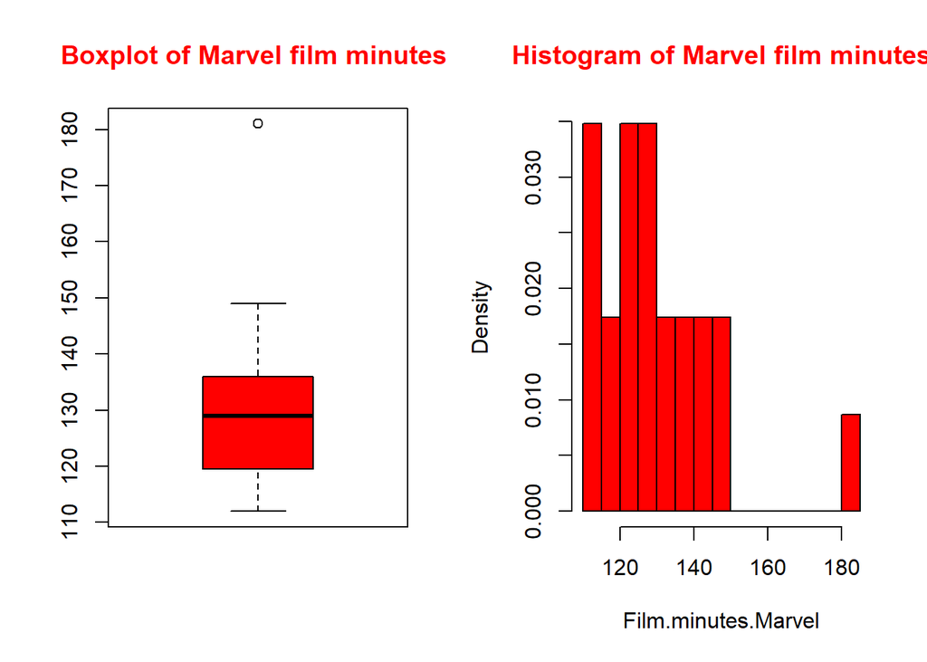

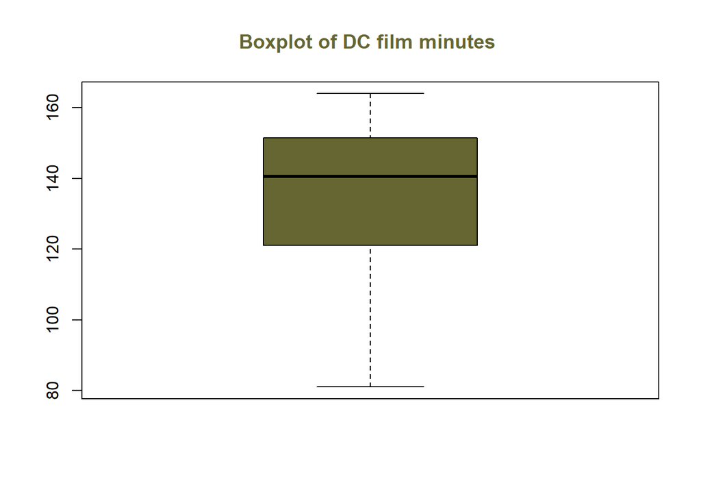

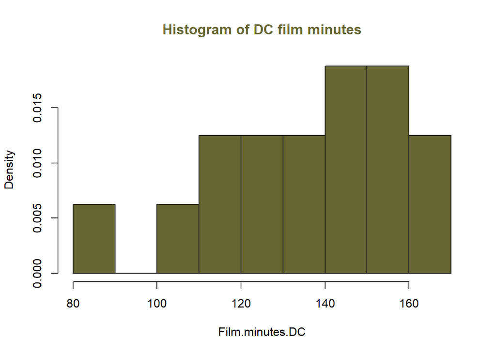

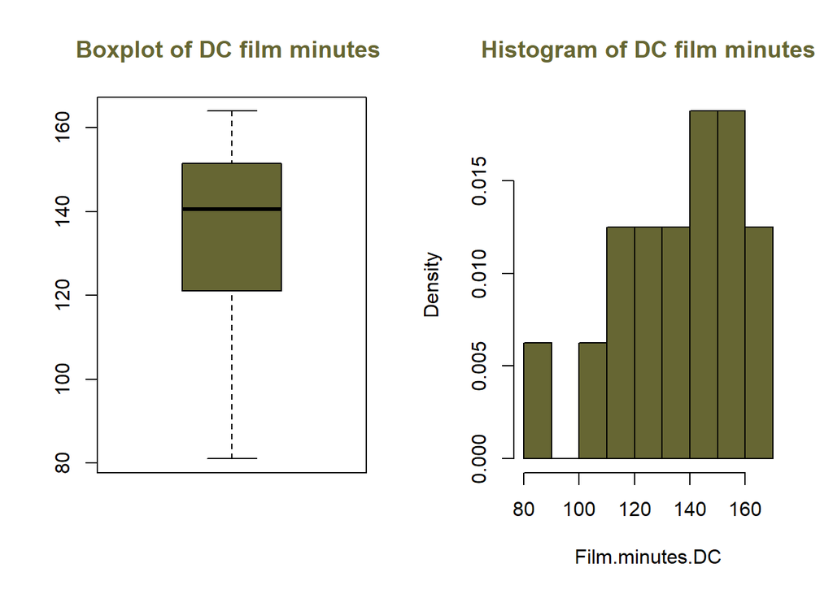

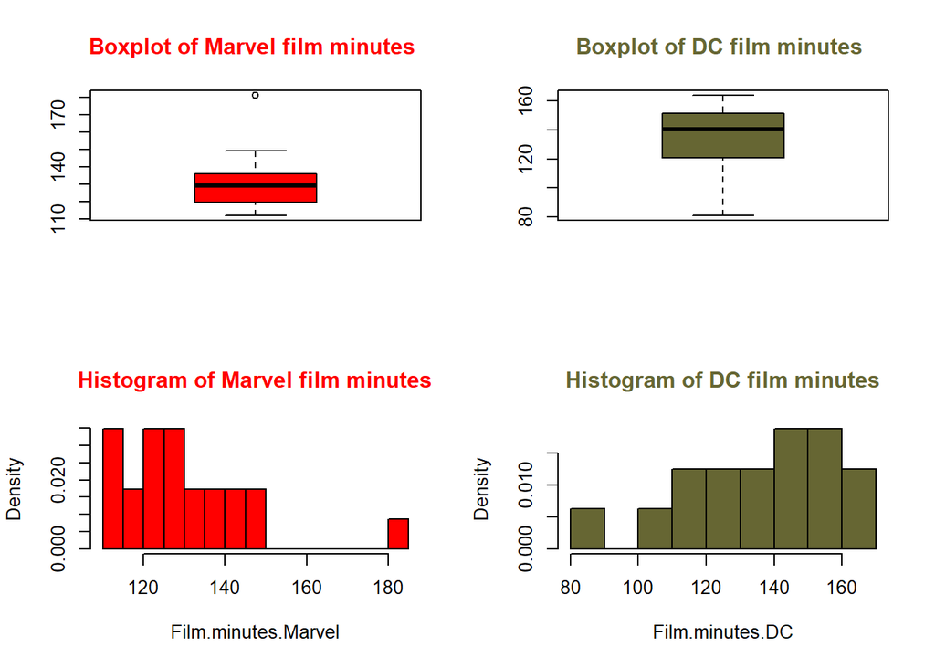

#### *E’ difficile confrontare boxplot e istogrammi che si distribuiscono su scale differenti.*

### *E’ necessario affiancare i boxplot della variabile Film.Minutes di Marvel e DC, in modo da valutare la distribuzione avendo come riferimento la stessa scala*

```
 [1] 126 112 124 115 124 143 130 112 136 121 141 117 147 115 136 133 130 134 149
[20] 118 123 181 129 104 140 154 152 162  81 114 164 143 151 123 141 120 143 132
[39] 122
```

```
$DC
   Min. 1st Qu.  Median    Mean 3rd Qu.    Max.
   81.0   121.5   140.5   134.1   151.2   164.0

$Marvel
   Min. 1st Qu.  Median    Mean 3rd Qu.    Max.
  112.0   119.5   129.0   130.3   136.0   181.0
```

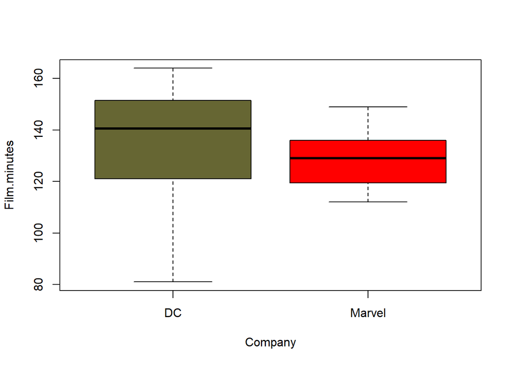

#### -Le due mediane differiscono:

> I film DC hanno durata mediana piu alta di quella dei film Marvel

#### -Il terzo quartile presenta una netta disparità:

> Se la durata dei film Marvel è molto piu concentrata attorno alla mediana, quella dei film DC presenta alta variabilità.

### *Creo un istorgamma che metta in relazione la variabile Film.Minutes e la variabile Company*

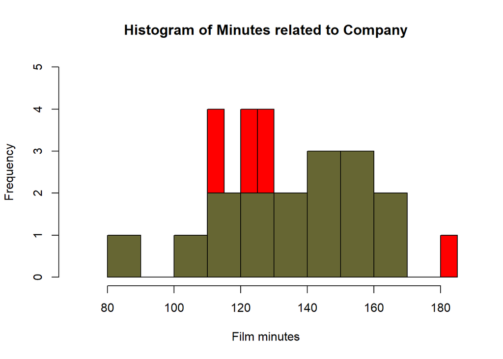

### *Misuro quindi la connessione che c’è tra l’appartenenza ad una determinata casa cinematografica e la durata del film*

```r
#misuro eta quadro tra variabile company e variabile Minutes

aov.Minutes=summary(aov(Film.minutes~Company))

dev.Minutes=aov.Minutes[[1]]$`Sum Sq`

eta.quadro.Minutes=dev.Minutes[1]/sum(dev.Minutes)
eta.quadro.Minutes
```

```
[1] 0.01090068
```

#### *Si deduce che la dipendenza in media dalla variabile Company spiega solo l’1% della variabilità totale della variabile Film.Minutes*

### *Quale film ha durata minore? E quale quella maggiore?*

```
   Min. 1st Qu.  Median    Mean 3rd Qu.    Max.
   81.0   120.5   130.0   131.8   143.0   181.0
```

```
[1] "Jonah Hex"
```

```
[1] "DC"
```

```
[1] "Avengers: Endgame"
```

```
[1] "Marvel"
```

### *Quanti film Marvel dalla durata x hanno ricevuto voto y da IMBD?*

```
      112 115 117 118 121 123 124 126 129 130 133 134 136 141 143 147 149 181
  6.7   1   0   0   0   0   0   0   0   0   0   0   0   0   0   0   0   0   0
  6.9   1   0   0   0   0   1   1   0   0   0   0   0   0   0   0   0   0   0
  7     0   1   0   0   0   0   1   0   0   0   0   0   0   0   0   0   0   0
  7.1   0   0   0   1   0   0   0   0   0   0   0   0   0   0   0   0   0   0
  7.2   0   0   0   0   0   0   0   0   0   1   0   0   0   0   0   0   0   0
  7.3   0   0   1   0   0   0   0   0   0   0   0   1   0   1   0   0   0   0
  7.4   0   0   0   0   0   0   0   0   0   0   1   0   0   0   0   0   0   0
  7.5   0   1   0   0   0   0   0   0   0   0   0   0   0   0   0   0   0   0
  7.6   0   0   0   0   0   0   0   0   1   0   0   0   1   0   0   0   0   0
  7.7   0   0   0   0   0   0   0   0   0   0   0   0   1   0   0   0   0   0
  7.8   0   0   0   0   0   0   0   0   0   0   0   0   0   0   0   1   0   0
  7.9   0   0   0   0   0   0   0   1   0   1   0   0   0   0   0   0   0   0
  8     0   0   0   0   1   0   0   0   0   0   0   0   0   0   1   0   0   0
  8.5   0   0   0   0   0   0   0   0   0   0   0   0   0   0   0   0   1   1
```

```
      112 115 117 118 121 123 124 126 129 130 133 134 136 141 143 147 149 181
  6.7 0.5 0.0 0.0 0.0 0.0 0.0 0.0 0.0 0.0 0.0 0.0 0.0 0.0 0.0 0.0 0.0 0.0 0.0
  6.9 0.5 0.0 0.0 0.0 0.0 1.0 0.5 0.0 0.0 0.0 0.0 0.0 0.0 0.0 0.0 0.0 0.0 0.0
  7   0.0 0.5 0.0 0.0 0.0 0.0 0.5 0.0 0.0 0.0 0.0 0.0 0.0 0.0 0.0 0.0 0.0 0.0
  7.1 0.0 0.0 0.0 1.0 0.0 0.0 0.0 0.0 0.0 0.0 0.0 0.0 0.0 0.0 0.0 0.0 0.0 0.0
  7.2 0.0 0.0 0.0 0.0 0.0 0.0 0.0 0.0 0.0 0.5 0.0 0.0 0.0 0.0 0.0 0.0 0.0 0.0
  7.3 0.0 0.0 1.0 0.0 0.0 0.0 0.0 0.0 0.0 0.0 0.0 1.0 0.0 1.0 0.0 0.0 0.0 0.0
  7.4 0.0 0.0 0.0 0.0 0.0 0.0 0.0 0.0 0.0 0.0 1.0 0.0 0.0 0.0 0.0 0.0 0.0 0.0
  7.5 0.0 0.5 0.0 0.0 0.0 0.0 0.0 0.0 0.0 0.0 0.0 0.0 0.0 0.0 0.0 0.0 0.0 0.0
  7.6 0.0 0.0 0.0 0.0 0.0 0.0 0.0 0.0 1.0 0.0 0.0 0.0 0.5 0.0 0.0 0.0 0.0 0.0
  7.7 0.0 0.0 0.0 0.0 0.0 0.0 0.0 0.0 0.0 0.0 0.0 0.0 0.5 0.0 0.0 0.0 0.0 0.0
  7.8 0.0 0.0 0.0 0.0 0.0 0.0 0.0 0.0 0.0 0.0 0.0 0.0 0.0 0.0 0.0 1.0 0.0 0.0
  7.9 0.0 0.0 0.0 0.0 0.0 0.0 0.0 1.0 0.0 0.5 0.0 0.0 0.0 0.0 0.0 0.0 0.0 0.0
  8   0.0 0.0 0.0 0.0 1.0 0.0 0.0 0.0 0.0 0.0 0.0 0.0 0.0 0.0 1.0 0.0 0.0 0.0
  8.5 0.0 0.0 0.0 0.0 0.0 0.0 0.0 0.0 0.0 0.0 0.0 0.0 0.0 0.0 0.0 0.0 1.0 1.0
```

### *Quanti film DC dalla durata x hanno ricevuto voto y da IMBD?*

```
      81 104 114 120 122 123 132 140 141 143 151 152 154 162 164
  3.3  0   1   0   0   0   0   0   0   0   0   0   0   0   0   0
  4.7  1   0   0   0   0   0   0   0   0   0   0   0   0   0   0
  5.5  0   0   1   0   0   0   0   0   0   0   0   0   0   0   0
  6    0   0   0   0   0   1   0   0   0   0   0   0   1   0   0
  6.4  0   0   0   1   0   0   0   0   0   0   0   0   0   0   0
  6.5  0   0   0   0   0   0   0   0   0   0   1   0   0   0   0
  7    0   0   0   0   0   0   0   0   0   1   0   0   0   0   0
  7.1  0   0   0   0   0   0   1   0   0   1   0   0   0   0   0
  7.4  0   0   0   0   0   0   0   0   1   0   0   0   0   0   0
  7.6  0   0   0   0   0   0   0   0   0   0   0   0   0   1   0
  8.2  0   0   0   0   0   0   0   1   0   0   0   0   0   0   0
  8.4  0   0   0   0   0   0   0   0   0   0   0   0   0   0   1
  8.7  0   0   0   0   1   0   0   0   0   0   0   0   0   0   0
  9    0   0   0   0   0   0   0   0   0   0   0   1   0   0   0
```

```
       81 104 114 120 122 123 132 140 141 143 151 152 154 162 164
  3.3 0.0 1.0 0.0 0.0 0.0 0.0 0.0 0.0 0.0 0.0 0.0 0.0 0.0 0.0 0.0
  4.7 1.0 0.0 0.0 0.0 0.0 0.0 0.0 0.0 0.0 0.0 0.0 0.0 0.0 0.0 0.0
  5.5 0.0 0.0 1.0 0.0 0.0 0.0 0.0 0.0 0.0 0.0 0.0 0.0 0.0 0.0 0.0
  6   0.0 0.0 0.0 0.0 0.0 1.0 0.0 0.0 0.0 0.0 0.0 0.0 1.0 0.0 0.0
  6.4 0.0 0.0 0.0 1.0 0.0 0.0 0.0 0.0 0.0 0.0 0.0 0.0 0.0 0.0 0.0
  6.5 0.0 0.0 0.0 0.0 0.0 0.0 0.0 0.0 0.0 0.0 1.0 0.0 0.0 0.0 0.0
  7   0.0 0.0 0.0 0.0 0.0 0.0 0.0 0.0 0.0 0.5 0.0 0.0 0.0 0.0 0.0
  7.1 0.0 0.0 0.0 0.0 0.0 0.0 1.0 0.0 0.0 0.5 0.0 0.0 0.0 0.0 0.0
  7.4 0.0 0.0 0.0 0.0 0.0 0.0 0.0 0.0 1.0 0.0 0.0 0.0 0.0 0.0 0.0
  7.6 0.0 0.0 0.0 0.0 0.0 0.0 0.0 0.0 0.0 0.0 0.0 0.0 0.0 1.0 0.0
  8.2 0.0 0.0 0.0 0.0 0.0 0.0 0.0 1.0 0.0 0.0 0.0 0.0 0.0 0.0 0.0
  8.4 0.0 0.0 0.0 0.0 0.0 0.0 0.0 0.0 0.0 0.0 0.0 0.0 0.0 0.0 1.0
  8.7 0.0 0.0 0.0 0.0 1.0 0.0 0.0 0.0 0.0 0.0 0.0 0.0 0.0 0.0 0.0
  9   0.0 0.0 0.0 0.0 0.0 0.0 0.0 0.0 0.0 0.0 0.0 1.0 0.0 0.0 0.0
```

### *Quanti film Marvel dalla durata x hanno ricevuto voto y da Metascore?*

```
     112 115 117 118 121 123 124 126 129 130 133 134 136 141 143 147 149 181
  54   1   0   0   0   0   0   0   0   0   0   0   0   0   0   0   0   0   0
  57   0   1   0   0   0   0   1   0   0   0   0   0   0   0   0   0   0   0
  61   1   0   0   0   0   0   0   0   0   0   0   0   0   0   0   0   0   0
  62   0   0   0   0   0   0   0   0   0   1   0   0   0   0   0   0   0   0
  64   0   0   1   0   0   1   0   0   0   0   0   0   0   0   0   0   0   0
  66   0   0   0   0   0   0   1   0   0   0   0   0   0   1   0   0   0   0
  67   0   0   0   0   0   0   0   0   0   0   0   0   1   0   0   0   0   0
  68   0   0   0   0   0   0   0   0   0   0   0   0   0   0   0   0   1   0
  69   0   0   0   0   0   0   0   0   1   0   0   0   0   0   1   0   0   0
  70   0   0   0   1   0   0   0   0   0   0   0   0   1   0   0   0   0   0
  72   0   1   0   0   0   0   0   0   0   0   0   0   0   0   0   0   0   0
  73   0   0   0   0   0   0   0   0   0   0   1   0   0   0   0   0   0   0
  74   0   0   0   0   0   0   0   0   0   1   0   0   0   0   0   0   0   0
  75   0   0   0   0   0   0   0   0   0   0   0   0   0   0   0   1   0   0
  76   0   0   0   0   1   0   0   0   0   0   0   0   0   0   0   0   0   0
  78   0   0   0   0   0   0   0   0   0   0   0   0   0   0   0   0   0   1
  79   0   0   0   0   0   0   0   1   0   0   0   0   0   0   0   0   0   0
  88   0   0   0   0   0   0   0   0   0   0   0   1   0   0   0   0   0   0
```

```
     112 115 117 118 121 123 124 126 129 130 133 134 136 141 143 147 149 181
  54 0.5 0.0 0.0 0.0 0.0 0.0 0.0 0.0 0.0 0.0 0.0 0.0 0.0 0.0 0.0 0.0 0.0 0.0
  57 0.0 0.5 0.0 0.0 0.0 0.0 0.5 0.0 0.0 0.0 0.0 0.0 0.0 0.0 0.0 0.0 0.0 0.0
  61 0.5 0.0 0.0 0.0 0.0 0.0 0.0 0.0 0.0 0.0 0.0 0.0 0.0 0.0 0.0 0.0 0.0 0.0
  62 0.0 0.0 0.0 0.0 0.0 0.0 0.0 0.0 0.0 0.5 0.0 0.0 0.0 0.0 0.0 0.0 0.0 0.0
  64 0.0 0.0 1.0 0.0 0.0 1.0 0.0 0.0 0.0 0.0 0.0 0.0 0.0 0.0 0.0 0.0 0.0 0.0
  66 0.0 0.0 0.0 0.0 0.0 0.0 0.5 0.0 0.0 0.0 0.0 0.0 0.0 1.0 0.0 0.0 0.0 0.0
  67 0.0 0.0 0.0 0.0 0.0 0.0 0.0 0.0 0.0 0.0 0.0 0.0 0.5 0.0 0.0 0.0 0.0 0.0
  68 0.0 0.0 0.0 0.0 0.0 0.0 0.0 0.0 0.0 0.0 0.0 0.0 0.0 0.0 0.0 0.0 1.0 0.0
  69 0.0 0.0 0.0 0.0 0.0 0.0 0.0 0.0 1.0 0.0 0.0 0.0 0.0 0.0 1.0 0.0 0.0 0.0
  70 0.0 0.0 0.0 1.0 0.0 0.0 0.0 0.0 0.0 0.0 0.0 0.0 0.5 0.0 0.0 0.0 0.0 0.0
  72 0.0 0.5 0.0 0.0 0.0 0.0 0.0 0.0 0.0 0.0 0.0 0.0 0.0 0.0 0.0 0.0 0.0 0.0
  73 0.0 0.0 0.0 0.0 0.0 0.0 0.0 0.0 0.0 0.0 1.0 0.0 0.0 0.0 0.0 0.0 0.0 0.0
  74 0.0 0.0 0.0 0.0 0.0 0.0 0.0 0.0 0.0 0.5 0.0 0.0 0.0 0.0 0.0 0.0 0.0 0.0
  75 0.0 0.0 0.0 0.0 0.0 0.0 0.0 0.0 0.0 0.0 0.0 0.0 0.0 0.0 0.0 1.0 0.0 0.0
  76 0.0 0.0 0.0 0.0 1.0 0.0 0.0 0.0 0.0 0.0 0.0 0.0 0.0 0.0 0.0 0.0 0.0 0.0
  78 0.0 0.0 0.0 0.0 0.0 0.0 0.0 0.0 0.0 0.0 0.0 0.0 0.0 0.0 0.0 0.0 0.0 1.0
  79 0.0 0.0 0.0 0.0 0.0 0.0 0.0 1.0 0.0 0.0 0.0 0.0 0.0 0.0 0.0 0.0 0.0 0.0
  88 0.0 0.0 0.0 0.0 0.0 0.0 0.0 0.0 0.0 0.0 0.0 1.0 0.0 0.0 0.0 0.0 0.0 0.0
```

### *Quanti film DC dalla durata x hanno ricevuto voto y da Metascore?*

```
     81 104 114 120 122 123 132 140 141 143 151 152 154 162 164
  27  0   1   0   0   0   0   0   0   0   0   0   0   0   0   0
  33  1   0   0   0   0   0   0   0   0   0   0   0   0   0   0
  39  0   0   1   0   0   0   0   0   0   0   0   0   0   0   0
  40  0   0   0   0   0   1   0   0   0   0   0   0   0   0   0
  44  0   0   0   0   0   0   0   0   0   0   1   0   0   0   0
  45  0   0   0   1   0   0   0   0   0   0   0   0   0   0   0
  55  0   0   0   0   0   0   0   0   0   2   0   0   0   0   0
  56  0   0   0   0   0   0   0   0   0   0   0   0   0   1   0
  59  0   0   0   0   1   0   0   0   0   0   0   0   0   0   0
  70  0   0   0   0   0   0   0   1   0   0   0   0   0   0   0
  71  0   0   0   0   0   0   1   0   0   0   0   0   0   0   0
  72  0   0   0   0   0   0   0   0   0   0   0   0   1   0   0
  76  0   0   0   0   0   0   0   0   1   0   0   0   0   0   0
  78  0   0   0   0   0   0   0   0   0   0   0   0   0   0   1
  84  0   0   0   0   0   0   0   0   0   0   0   1   0   0   0
```

```
     81 104 114 120 122 123 132 140 141 143 151 152 154 162 164
  27  0   1   0   0   0   0   0   0   0   0   0   0   0   0   0
  33  1   0   0   0   0   0   0   0   0   0   0   0   0   0   0
  39  0   0   1   0   0   0   0   0   0   0   0   0   0   0   0
  40  0   0   0   0   0   1   0   0   0   0   0   0   0   0   0
  44  0   0   0   0   0   0   0   0   0   0   1   0   0   0   0
  45  0   0   0   1   0   0   0   0   0   0   0   0   0   0   0
  55  0   0   0   0   0   0   0   0   0   1   0   0   0   0   0
  56  0   0   0   0   0   0   0   0   0   0   0   0   0   1   0
  59  0   0   0   0   1   0   0   0   0   0   0   0   0   0   0
  70  0   0   0   0   0   0   0   1   0   0   0   0   0   0   0
  71  0   0   0   0   0   0   1   0   0   0   0   0   0   0   0
  72  0   0   0   0   0   0   0   0   0   0   0   0   1   0   0
  76  0   0   0   0   0   0   0   0   1   0   0   0   0   0   0
  78  0   0   0   0   0   0   0   0   0   0   0   0   0   0   1
  84  0   0   0   0   0   0   0   0   0   0   0   1   0   0   0
```

### *Converto variabile quantitativa Film.Minutes in categorica*

```
var.categorica.minutes
  (0,100] (100,135] (135,185]
        1        22        16
```

```
        var.categorica.minutes
Company  breve durata normo durata lunga durata
  DC                1            6            9
  Marvel            0           16            7
```

### *Misuro connessione statistica tra variabile Company e variabile Film.Minutes categorica*

```
    Pearson's Chi-squared test

data:  Company and var.categorica.minutes
X-squared = 4.6901, df = 2, p-value = 0.09584
```

```
X-squared
  4.69014
```

```
[1] 0.2916105
```

#### *Dal risultato si deduce che c’è il 29 % della massima connessione statistica.*

### *Verifico la correlazione tra la variabile Film.Minutes e Film.Rate.IMDB, realizzando il grafico di dispersione.*

```
Call:
lm(formula = Film.Rate.IMDB ~ Film.minutes)

Residuals:
    Min      1Q  Median      3Q     Max
-2.9552 -0.3872  0.0819  0.4561  1.8324

Coefficients:
             Estimate Std. Error t value Pr(>|t|)
(Intercept)  2.717114   1.035211   2.625   0.0125 *
Film.minutes 0.034020   0.007778   4.374 9.56e-05 ***
---
Signif. codes:  0 '***' 0.001 '**' 0.01 '*' 0.05 '.' 0.1 ' ' 1

Residual standard error: 0.8843 on 37 degrees of freedom
Multiple R-squared:  0.3408,    Adjusted R-squared:  0.323
F-statistic: 19.13 on 1 and 37 DF,  p-value: 9.562e-05
```

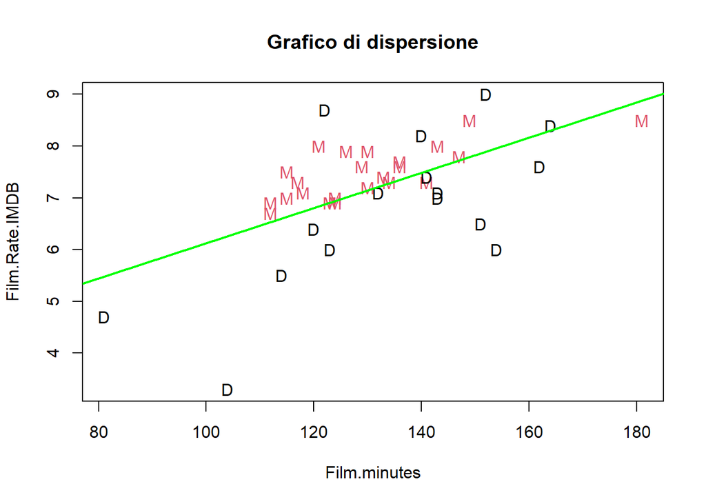

#### *Si nota,quindi, che la correlazione tra Film.Rate.IMDB E Film.Minutes è abbastanza alta, soprattutto per i film Marvel, pertanto mi vuol dire quanta variazione di Film.Rate.IMDB è spiegata da una variazione unitaria di Film.Minutes*

### *Verifico la correlazione tra la variabile Film.Minutes e Film.Rate.Metascore, realizzandoil grafico di dispersione.*

```
          Metascore Minutes
Metascore   1.00000 0.50978
Minutes     0.50978 1.00000
```

```
Call:
lm(formula = Film.Rate.Metascore ~ Film.minutes)

Residuals:
    Min      1Q  Median      3Q     Max
-27.005  -4.080   1.742   6.849  23.508

Coefficients:
             Estimate Std. Error t value Pr(>|t|)
(Intercept)   13.1523    14.1477   0.930 0.358581
Film.minutes   0.3831     0.1063   3.604 0.000917 ***
---
Signif. codes:  0 '***' 0.001 '**' 0.01 '*' 0.05 '.' 0.1 ' ' 1

Residual standard error: 12.08 on 37 degrees of freedom
Multiple R-squared:  0.2599,    Adjusted R-squared:  0.2399
F-statistic: 12.99 on 1 and 37 DF,  p-value: 0.0009165
```

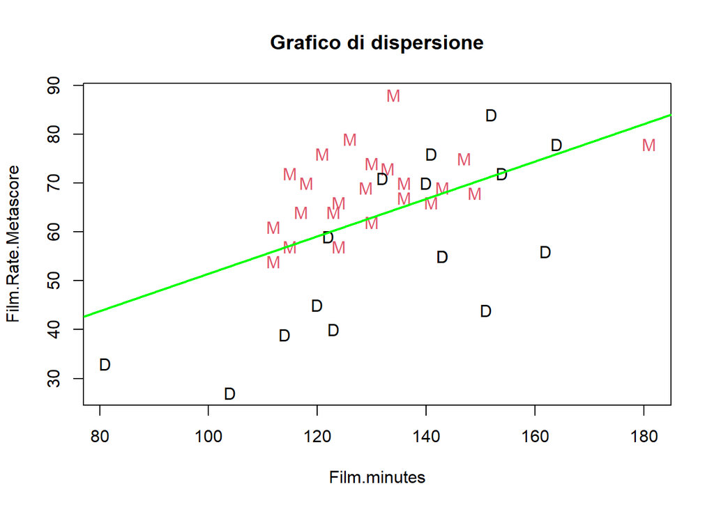

## **VARIABILE DATE.RELEASE**

### *Analizzo il summary della variabile date.release per dedurre il range di valori che assume*

```r
# variabile nella settima colonna

MCU_vs_DCU.df[,7]
```

```
 [1] 2008 2008 2010 2011 2011 2012 2013 2013 2014 2014 2015 2015 2016 2016 2017
[16] 2017 2017 2018 2018 2018 2019 2019 2019 2004 2005 2006 2008 2009 2010 2011
[31] 2012 2013 2016 2016 2017 2017 2018 2019 2019
```

```r
date.release=MCU_vs_DCU.df[,7]
summary(date.release)
```

```
   Min. 1st Qu.  Median    Mean 3rd Qu.    Max.
   2004    2011    2015    2014    2017    2019
```

### *Analizzo il summary della variabile date.release categorizzata in base alla variabile Company per dedurre il range di valori che assume.*

#### Marvel

```
   Min. 1st Qu.  Median    Mean 3rd Qu.    Max.
   2008    2012    2015    2015    2018    2019
```

#### DC

```
   Min. 1st Qu.  Median    Mean 3rd Qu.    Max.
   2004    2009    2012    2012    2017    2019
```

### *Creiamo ,quindi, boxplot e istogrammi che ci facciano intuire in maniera piu chiara la distribuzione della variabile date.release generica e relativamente ai film Marvel DC.*

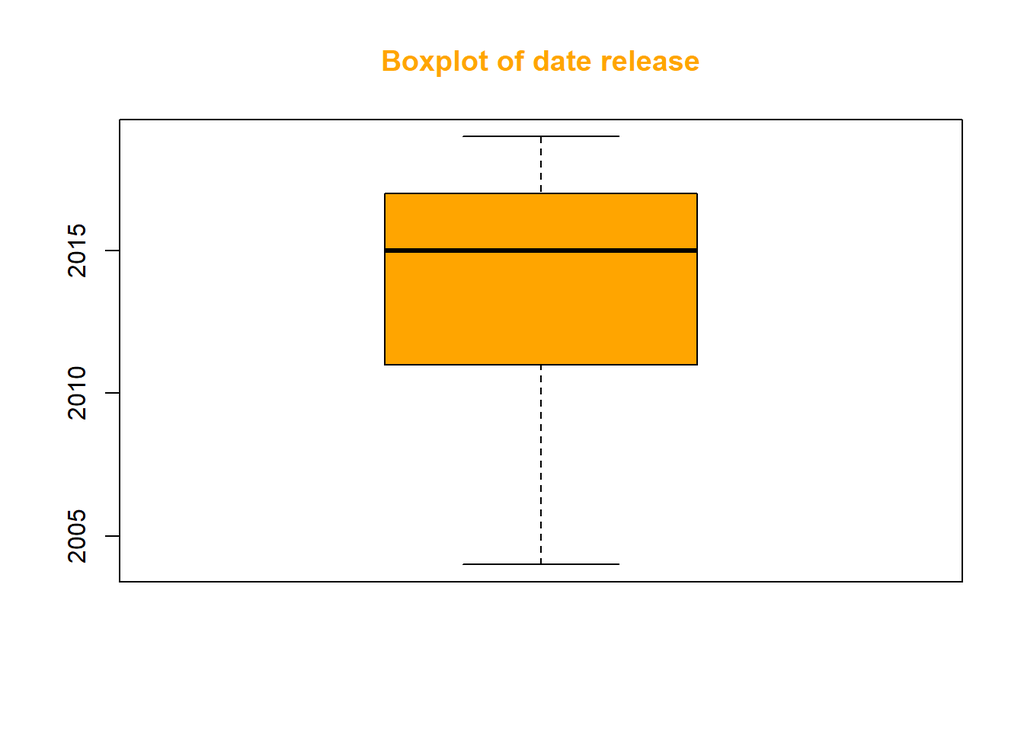

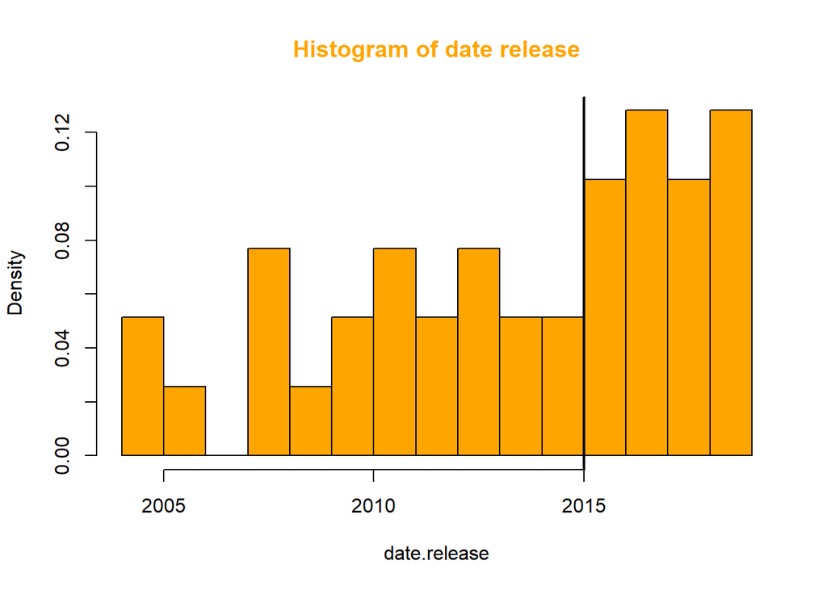

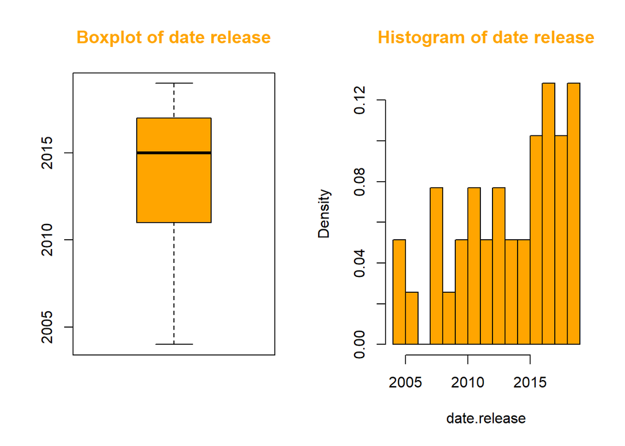

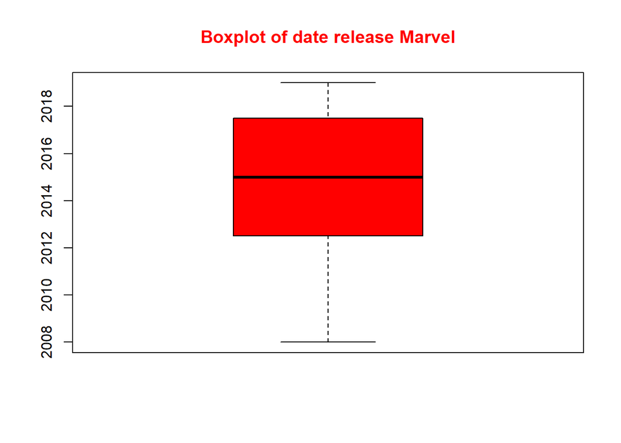

[figure not shown]

[figure not shown]

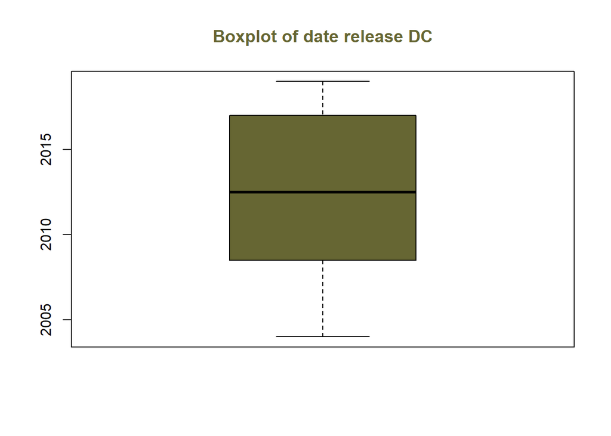

[figure not shown]

[figure not shown]

[figure not shown]

#### *E’ difficile confrontare boxplot e istogrammi che si distribuiscono su scale differenti.*

### *E’ necessario affiancare i boxplot del date.release di Marvel e DC, in modo da valutare la distribuzione avendo come riferimento la stessa scala*

```
 [1] 2008 2008 2010 2011 2011 2012 2013 2013 2014 2014 2015 2015 2016 2016 2017
[16] 2017 2017 2018 2018 2018 2019 2019 2019 2004 2005 2006 2008 2009 2010 2011
[31] 2012 2013 2016 2016 2017 2017 2018 2019 2019
```

```
$DC
   Min. 1st Qu.  Median    Mean 3rd Qu.    Max.
   2004    2009    2012    2012    2017    2019

$Marvel
   Min. 1st Qu.  Median    Mean 3rd Qu.    Max.
   2008    2012    2015    2015    2018    2019
```

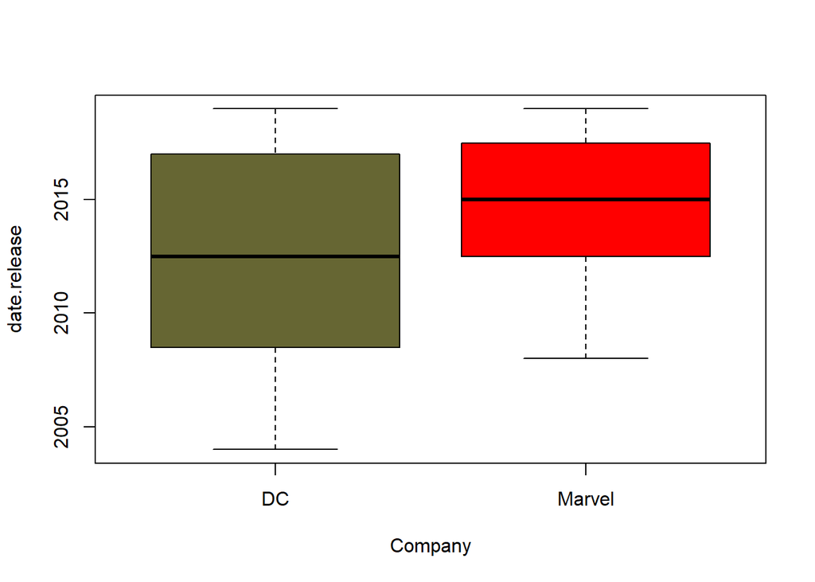

#### -Le due mediane differiscono, anche se di poco:

> La mediana della variabile date.release di DC è inferiore a quella di Marvel

#### -Il primo quartile presenta una netta disparità:

> I film Marvel sono usciti in un arco di tempo piu concentrato attorno alla mediana , a differenza di quelli DC la cui uscita è spalmata su più anni.

### *Creo un istorgamma che metta in relazione la variabile date.release e la variabile Company*

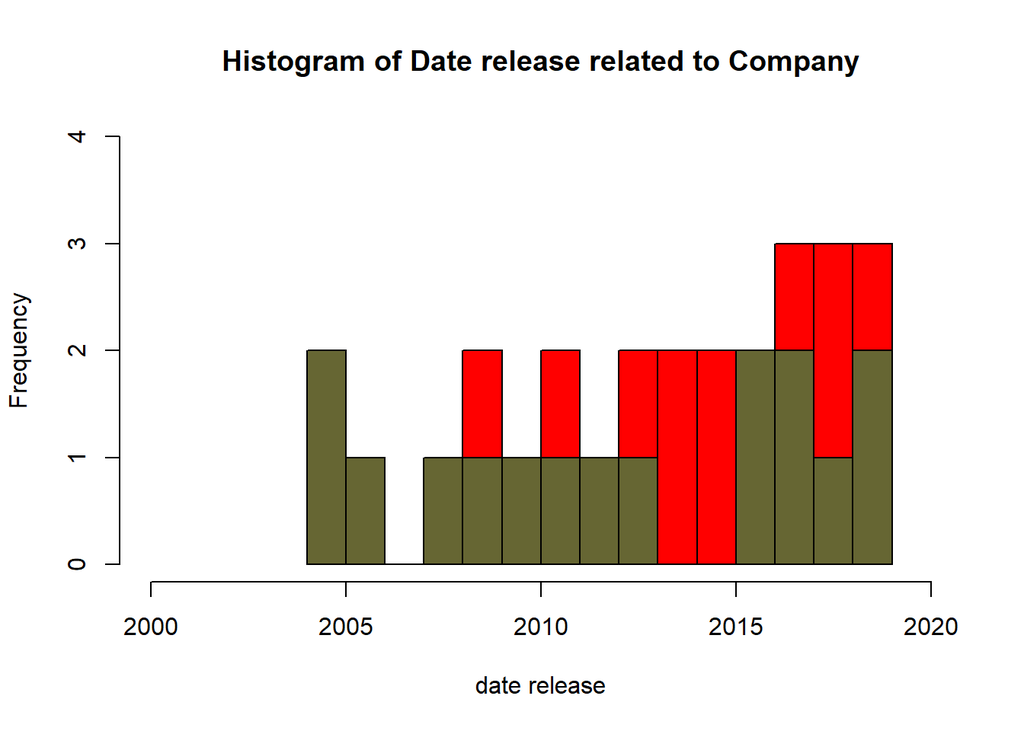

### *Misuro quindi la connessione che c’è tra l’appartenenza ad una determinata casa cinematografica e la data di rilascio del film*

```r
#misuro eta quadro tra variabile company e variabile date.release

aov.date.release=summary(aov(date.release~Company))

dev.date.release=aov.date.release[[1]]$`Sum Sq`

eta.quadro.date=dev.date.release[1]/sum(dev.date.release)
eta.quadro.date
```

```
[1] 0.06513757
```

#### *Si deduce che la dipendenza in media dalla variabile Company spiega solo il 6.5% della variabilità totale della variabile date.release*

### *Quale film è uscito per primo? Quale per ultimo?*

```
   Min. 1st Qu.  Median    Mean 3rd Qu.    Max.
   2004    2011    2015    2014    2017    2019
```

```
[1] "Catwoman"
```

```
[1] "DC"
```

```
[1] "Captain Marvel"            "Avengers: Endgame"
[3] "Spider-Man: Far from Home" "Shazam!"
[5] "Joker"
```

```
[1] "Marvel" "Marvel" "Marvel" "DC"     "DC"
```

### *Quale film Marvel e DC è uscito per primo? Quale per ultimo?*

```
   Min. 1st Qu.  Median    Mean 3rd Qu.    Max.
   2004    2011    2015    2014    2017    2019
```

```
[1] "Iron Man"            "The Incredible Hulk"
```

```
[1] "Catwoman"
```

```
[1] "Captain Marvel"            "Avengers: Endgame"
[3] "Spider-Man: Far from Home"
```

```
[1] "Shazam!" "Joker"
```

### *Quanti film sono usciti nell’anno X?*

```
n_film_anno_X
2004 2005 2006 2008 2009 2010 2011 2012 2013 2014 2015 2016 2017 2018 2019 2020
   1    1    1    3    1    2    3    2    3    2    2    4    5    4    5    0
```

### *Quanti film Marvel e DC sono usciti nell’anno X?*

```
        n_film_anno_X
Company  2004 2005 2006 2008 2009 2010 2011 2012 2013 2014 2015 2016 2017 2018
  DC        1    1    1    1    1    1    1    1    1    0    0    2    2    1
  Marvel    0    0    0    2    0    1    2    1    2    2    2    2    3    3
        n_film_anno_X
Company  2019 2020
  DC        2    0
  Marvel    3    0
```

### *Converto variabile quantitativa date.release in categorica*

```
   Min. 1st Qu.  Median    Mean 3rd Qu.    Max.
   2004    2011    2015    2014    2017    2019
```

```
var.categorica.date.release
(2003,2009] (2009,2014] (2014,2019]
          7          12          20
```

```
 [1] (2003,2009] (2003,2009] (2009,2014] (2009,2014] (2009,2014] (2009,2014]
 [7] (2009,2014] (2009,2014] (2009,2014] (2009,2014] (2014,2019] (2014,2019]
[13] (2014,2019] (2014,2019] (2014,2019] (2014,2019] (2014,2019] (2014,2019]
[19] (2014,2019] (2014,2019] (2014,2019] (2014,2019] (2014,2019] (2003,2009]
[25] (2003,2009] (2003,2009] (2003,2009] (2003,2009] (2009,2014] (2009,2014]
[31] (2009,2014] (2009,2014] (2014,2019] (2014,2019] (2014,2019] (2014,2019]
[37] (2014,2019] (2014,2019] (2014,2019]
Levels: (2003,2009] < (2009,2014] < (2014,2019]
```

```
        var.categorica.date.release
Company  vintage vecchio recente
  DC           5       4       7
  Marvel       2       8      13
```

### *Misuro connessione statistica tra variabile Company e variabile date.release*

```
    Pearson's Chi-squared test

data:  Company and var.categorica.date.release
X-squared = 3.2679, df = 2, p-value = 0.1952
```

```
X-squared
 3.267915
```

```
[1] 0.243414
```

#### *Dal risultato si deduce che c’è il 24 % della massima connessione statistica.*

### *Verifico la correlazione tra la variabile date.release e Film.Minutes, realizzando il grafico di dispersione.*

```
          Minutes   Release
Minutes 1.0000000 0.1383874
Release 0.1383874 1.0000000
```

```
Call:
lm(formula = Film.minutes ~ date.release)

Residuals:
    Min      1Q  Median      3Q     Max
-48.587 -13.350  -2.396  11.925  46.055

Coefficients:
               Estimate Std. Error t value Pr(>|t|)
(Intercept)  -1067.0701  1410.5666  -0.756    0.454
date.release     0.5954     0.7005   0.850    0.401

Residual standard error: 18.51 on 37 degrees of freedom
Multiple R-squared:  0.01915,   Adjusted R-squared:  -0.007358
F-statistic: 0.7224 on 1 and 37 DF,  p-value: 0.4008
```

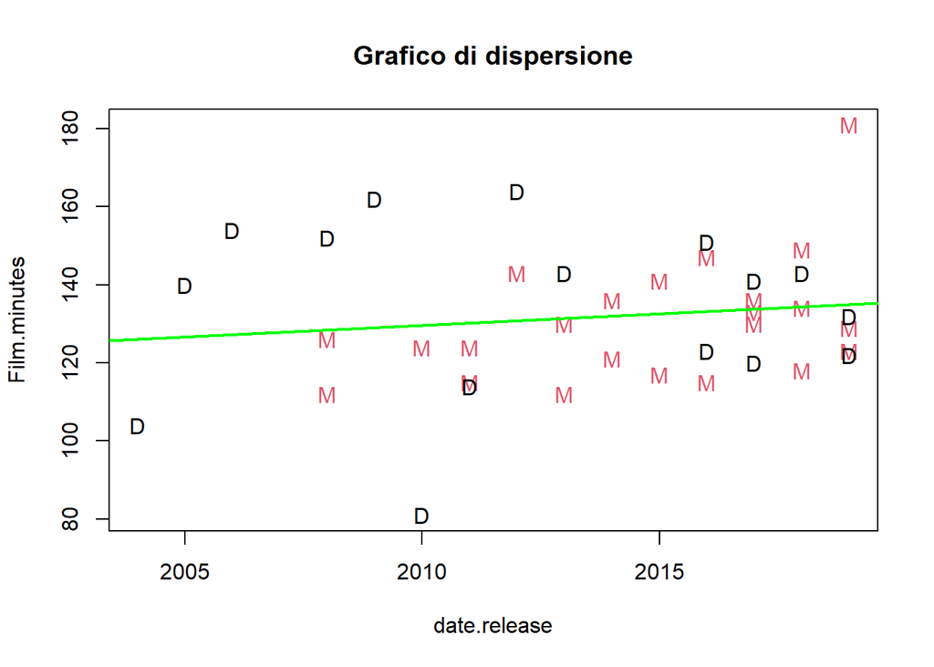

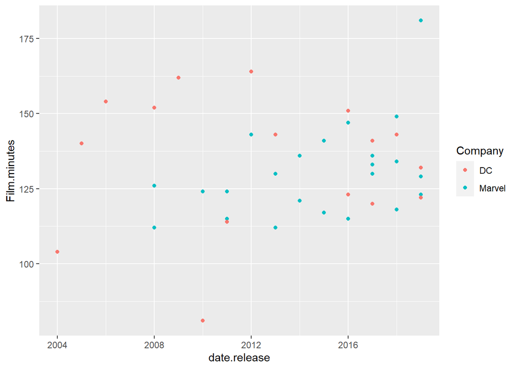

### *Verifico la correlazione tra la variabile date.release e Film.Rate.IMDB, realizzando il grafico di dispersione.*

[output not shown]

```
Call:
lm(formula = Film.Rate.IMDB ~ date.release)

Residuals:
     Min       1Q   Median       3Q      Max
-3.08739 -0.49415 -0.00286  0.63036  2.27971

Coefficients:
               Estimate Std. Error t value Pr(>|t|)
(Intercept)  -160.39432   78.28913  -2.049   0.0476 *
date.release    0.08322    0.03888   2.141   0.0390 *
---
Signif. codes:  0 '***' 0.001 '**' 0.01 '*' 0.05 '.' 0.1 ' ' 1

Residual standard error: 1.027 on 37 degrees of freedom
Multiple R-squared:  0.1102,    Adjusted R-squared:  0.08616
F-statistic: 4.583 on 1 and 37 DF,  p-value: 0.03895
```

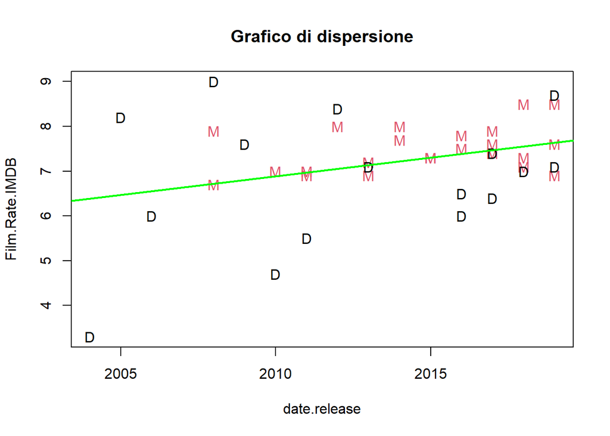

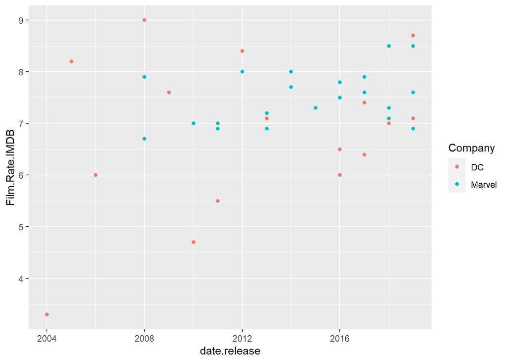

### *Verifico la correlazione tra la variabile date.release e Film.Rate.Metascore, realizzando il grafico di dispersione.*

[output not shown]

```
Call:
lm(formula = Film.Rate.Metascore ~ date.release)

Residuals:
    Min      1Q  Median      3Q     Max
-29.313  -6.319   1.429   8.802  24.684

Coefficients:
               Estimate Std. Error t value Pr(>|t|)
(Intercept)  -1448.3061  1041.1672  -1.391    0.173
date.release     0.7508     0.5170   1.452    0.155

Residual standard error: 13.66 on 37 degrees of freedom
Multiple R-squared:  0.05392,   Adjusted R-squared:  0.02835
F-statistic: 2.109 on 1 and 37 DF,  p-value: 0.1549
```

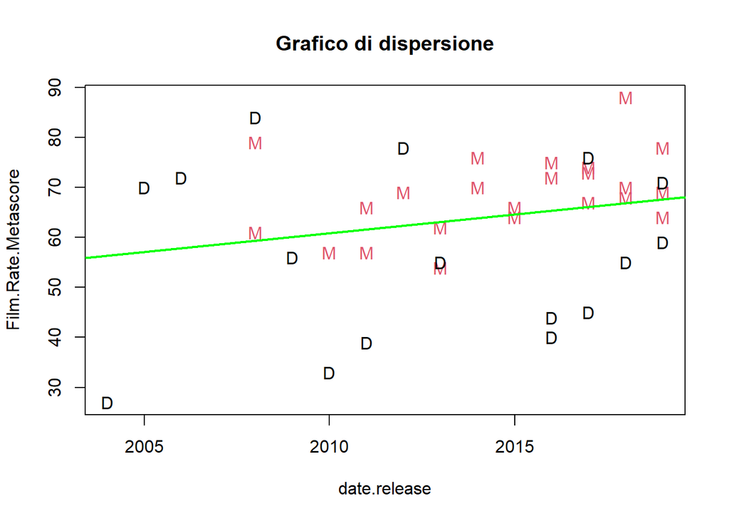

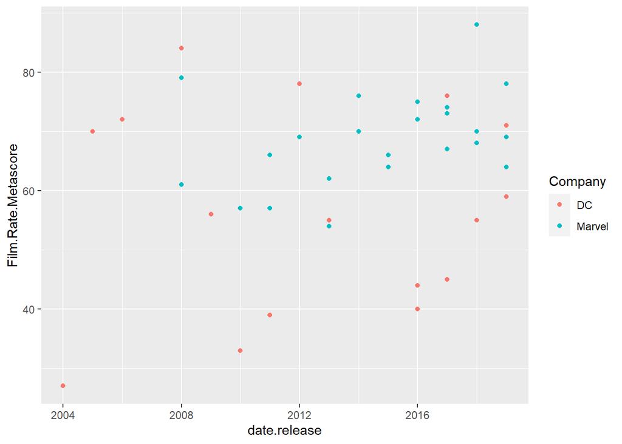

## **VARIABILE BUDGET**

### *Analizzo il summary della variabile Budget per dedurre il range di valori che assume*

```r
MCU_vs_DCU.df[,8]
```

```
 [1] 140000000 150000000 200000000 150000000 140000000 220000000 200000000
 [8] 170000000 170000000 170000000 250000000 130000000 250000000 165000000
[15] 200000000 175000000 180000000 200000000 321000000 162000000 175000000
[22] 356000000 160000000 100000000 150000000 270000000 185000000 130000000
[29]  47000000 200000000 250000000 225000000 250000000 175000000 149000000
[36] 300000000 160000000 100000000  55000000
```

```r
str(MCU_vs_DCU.df[,8])
```

```
 int [1:39] 140000000 150000000 200000000 150000000 140000000 220000000 200000000 170000000 170000000 170000000 ...
```

```r
Budget=MCU_vs_DCU.df[,8]
summary(Budget)
```

```
     Min.   1st Qu.    Median      Mean   3rd Qu.      Max.
 47000000 150000000 175000000 184102564 210000000 356000000
```

### *Analizzo il summary della variabile Budget categorizzata in base alla variabile Company per dedurre il range di valori che assume.*

#### Marvel

```
     Min.   1st Qu.    Median      Mean   3rd Qu.      Max.
130000000 161000000 175000000 192782609 200000000 356000000
```

#### DC

```
     Min.   1st Qu.    Median      Mean   3rd Qu.      Max.
 47000000 122500000 167500000 171625000 231250000 300000000
```

### *Creiamo ,quindi, boxplot e istogrammi che ci facciano intuire in maniera piu chiara la distribuzione della variabile Budget generica e relativamente ai film Marvel DC.*

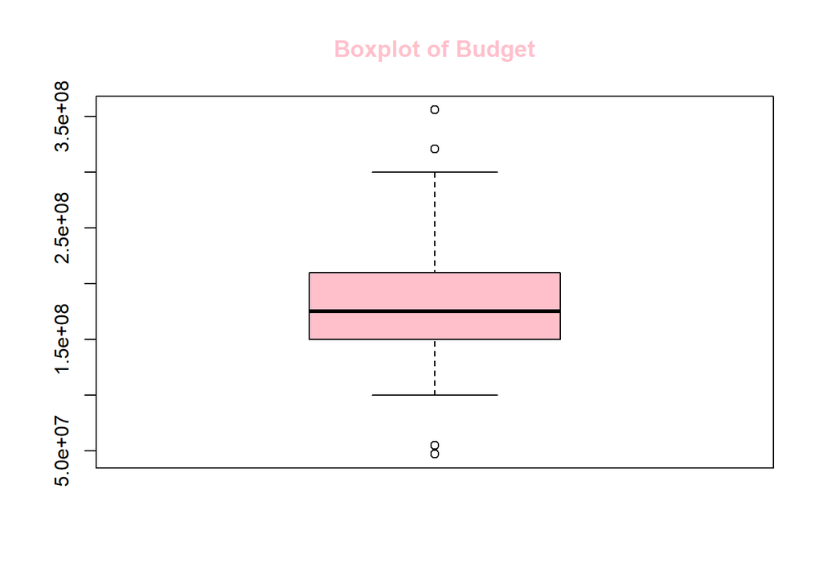

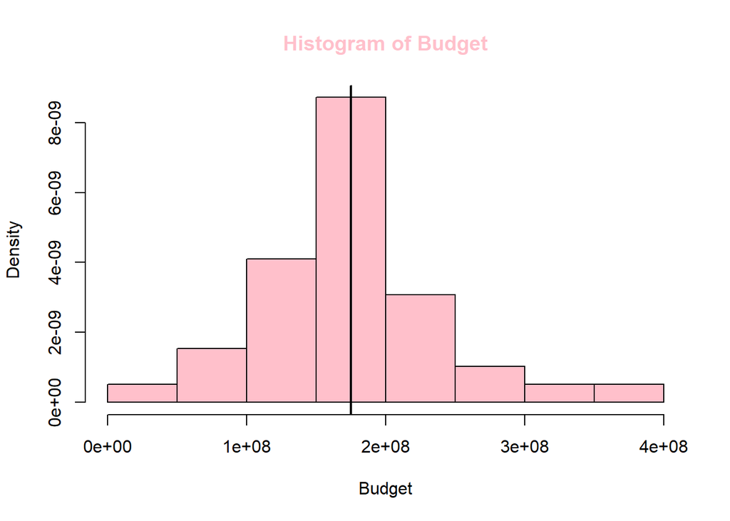

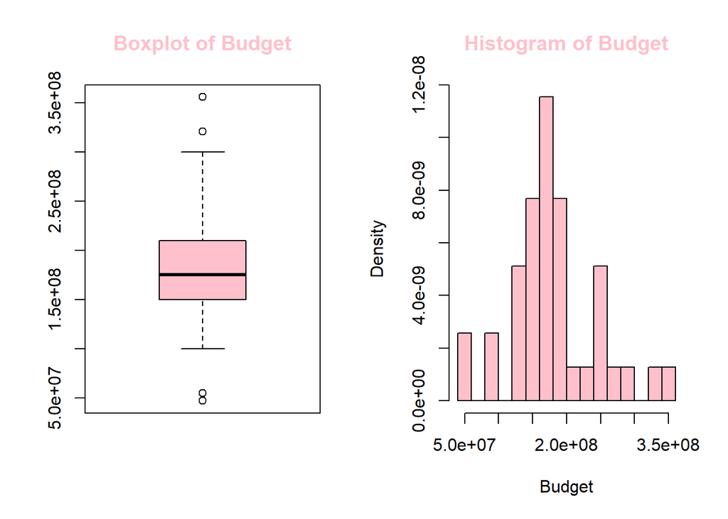

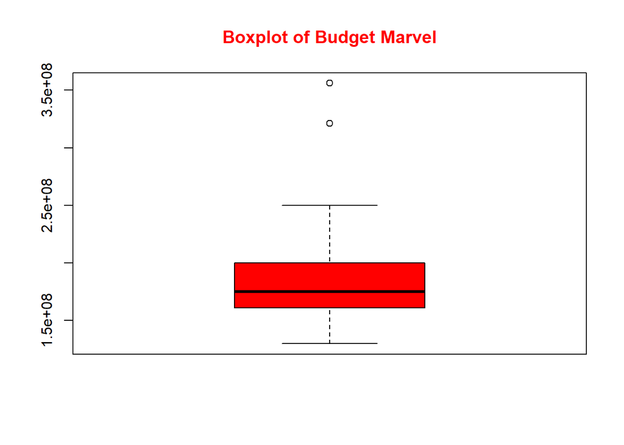

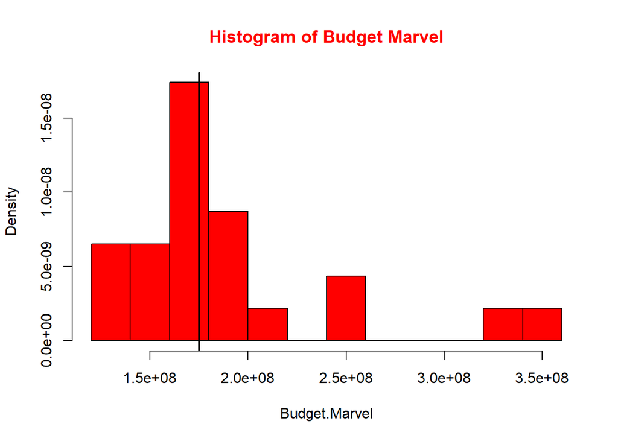

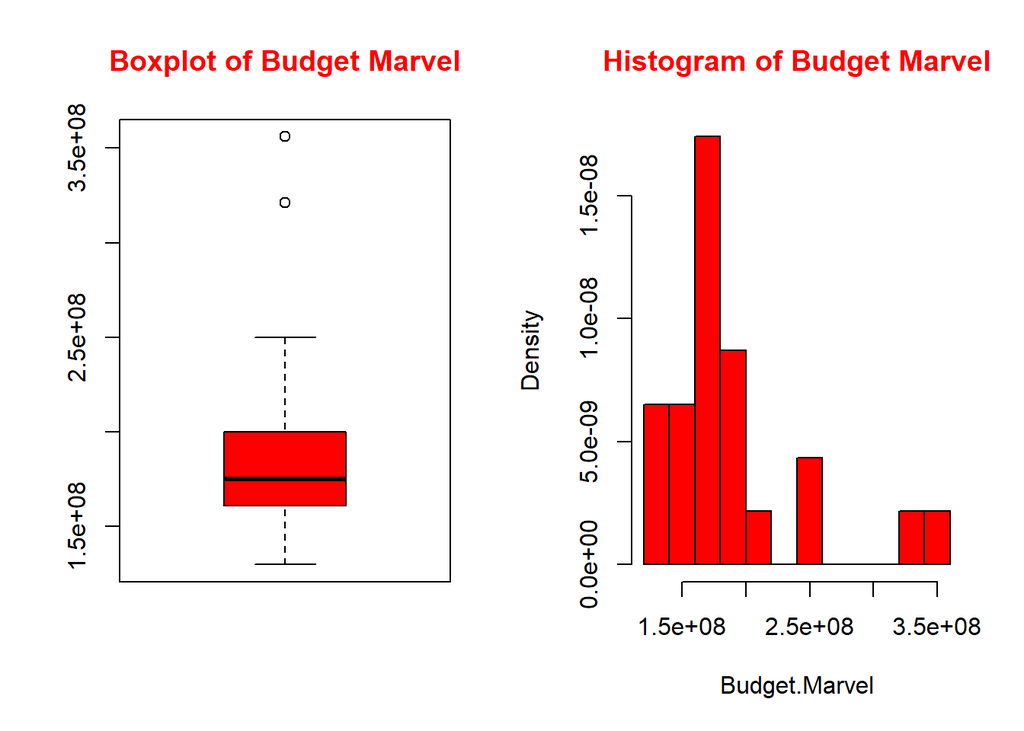

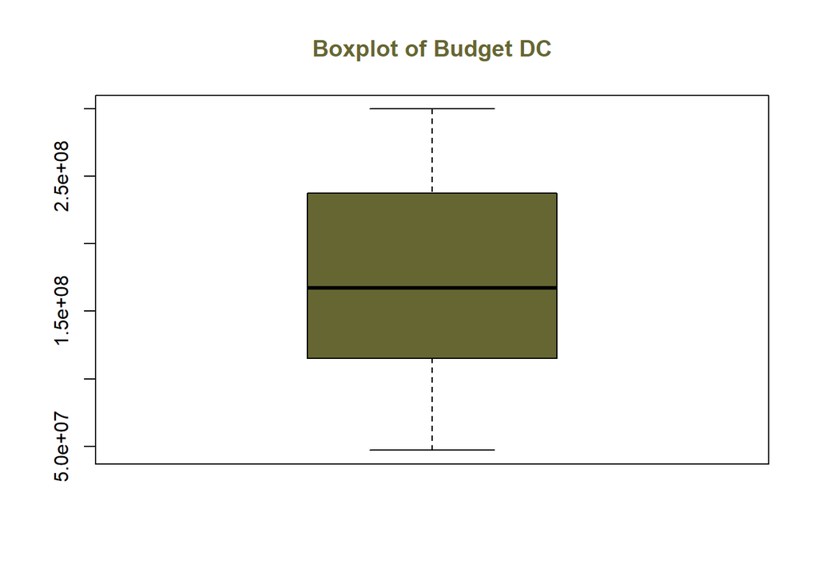

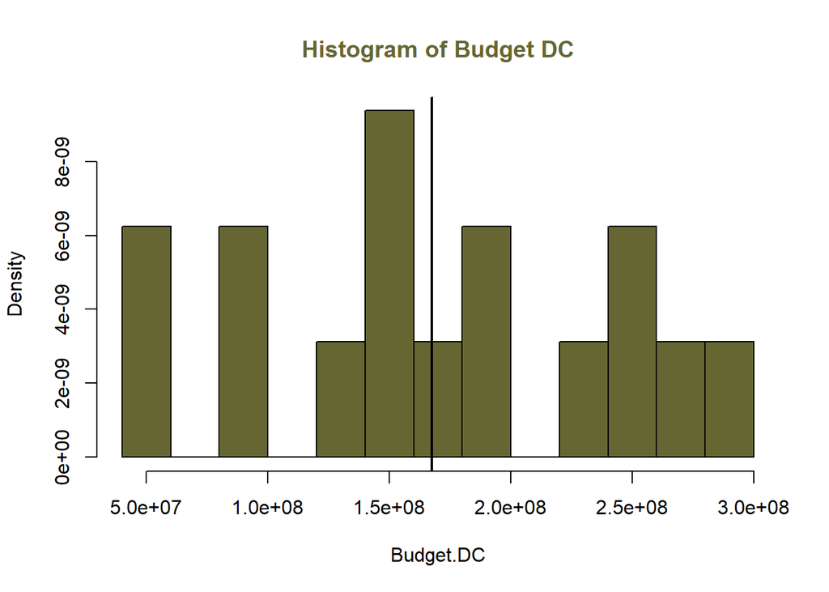

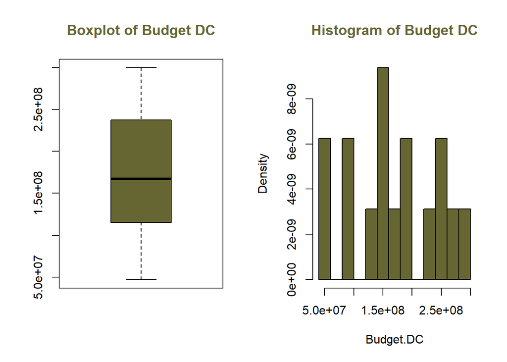

#### *E’ difficile confrontare boxplot e istogrammi che si distribuiscono su scale differenti.*

### *E’ necessario affiancare i boxplot della variabile Budget di Marvel e DC, in modo da valutare la distribuzione avendo come riferimento la stessa scala*

```
$DC
     Min.   1st Qu.    Median      Mean   3rd Qu.      Max.
 47000000 122500000 167500000 171625000 231250000 300000000

$Marvel
     Min.   1st Qu.    Median      Mean   3rd Qu.      Max.
130000000 161000000 175000000 192782609 200000000 356000000
```

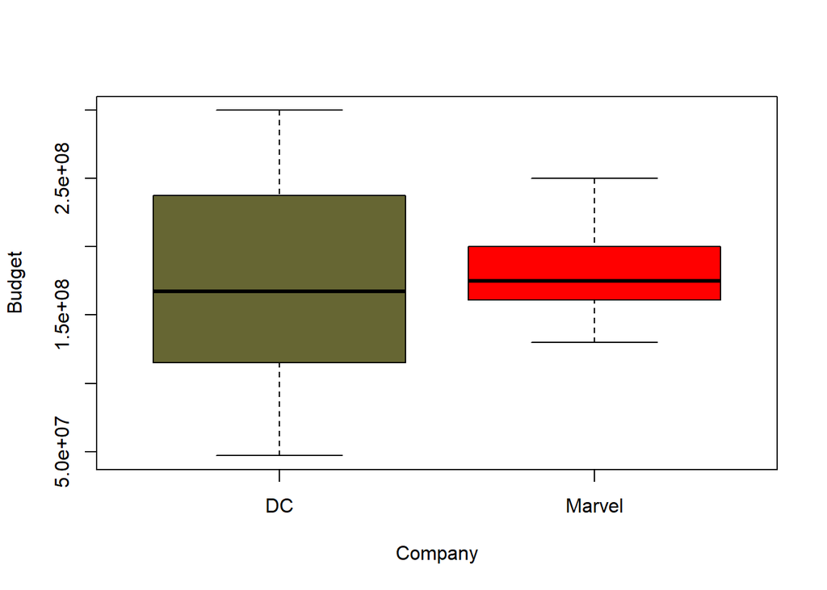

#### -Il primo quartile ed il terzo presentano una netta disparità:

> La maggioranza dei film Marvel sono stati realizzati con un Budget il cui valore è molto più concentrato attorno alla mediana relativa rispetto a quello dei film DC. Da ciò si deduce maggior variabilità nelle osservazioni categorizzate per la Company DC rispetto a quella Marvel.

### *Creo un istorgamma che metta in relazione la variabile Budget e la variabile Company*

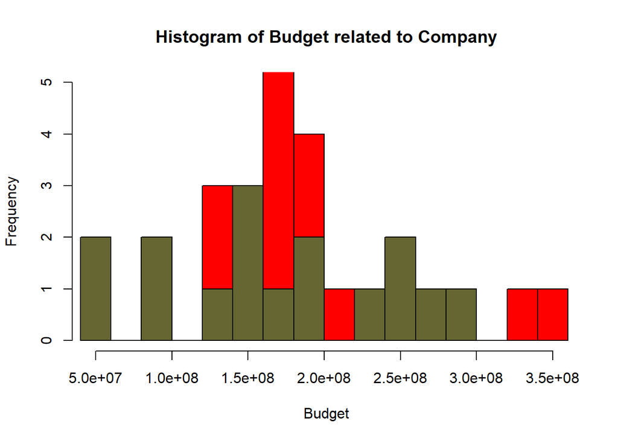

### *Misuro quindi la connessione che c’è tra l’appartenenza ad una determinata casa cinematografica ed il budget utilizzato per un determinato film*

```r
aov.Budget=summary(aov(Budget~Company))

dev.Budget=aov.Budget[[1]]$`Sum Sq`

eta.quadro.Budget=dev.Budget[1]/sum(dev.Budget)
eta.quadro.Budget
```

```
[1] 0.02679313
```

#### *Si deduce che la dipendenza in media dalla variabile Company spiega solo il 2.6% della variabilità totale della variabile Budget*

### *Misuro quindi la connessione che c’è tra la variabile categorica Minutes ed il budget utilizzato per un determinato film*

```r
aov.Budget.2=summary(aov(Budget~var.categorica.minutes))

dev.Budget.2=aov.Budget.2[[1]]$`Sum Sq`

eta.quadro.Budget.2=dev.Budget.2[1]/sum(dev.Budget.2)
eta.quadro.Budget.2
```

```
[1] 0.3166395
```

#### *Si deduce che la dipendenza in media dalla variabile categorica Minutes spiega il 31.6% della variabilità totale della variabile Budget*

### *Quale film ha utilizzato il Budget più basso? Quale il più alto?*

```
     Min.   1st Qu.    Median      Mean   3rd Qu.      Max.
 47000000 150000000 175000000 184102564 210000000 356000000
```

```
[1] "Jonah Hex"
```

```
[1] "DC"
```

```
[1] "Avengers: Endgame"
```

```
[1] "Marvel"
```

### *Che voto ha ottenuto da IMDB il film con il budget piu basso e quello con il budget piu alto?*

```
   Min. 1st Qu.  Median    Mean 3rd Qu.    Max.
  3.300   6.900   7.300   7.203   7.850   9.000
```

```
[1] 4.7
```

```
[1] 8.5
```

### *Che voto ha ottenuto da Metascore il film con il budget piu basso e quello con il budget piu alto?*

```
   Min. 1st Qu.  Median    Mean 3rd Qu.    Max.
  27.00   56.50   67.00   63.67   72.50   88.00
```

```
[1] 33
```

```
[1] 78
```

### *Che budget ha avuto il film con voto piu basso e alto per IMDB?*

```
   Min. 1st Qu.  Median    Mean 3rd Qu.    Max.
  3.300   6.900   7.300   7.203   7.850   9.000
```

[output not shown]

[output not shown]

### *Che budget ha avuto il film con voto piu basso e alto per Metascore?*

```
   Min. 1st Qu.  Median    Mean 3rd Qu.    Max.
  27.00   56.50   67.00   63.67   72.50   88.00
```

```
[1] 100000000
```

```
[1] 200000000
```

### *Quale film Marvel ha avuto un budget più basso? Quale quello più alto?*

```
     Min.   1st Qu.    Median      Mean   3rd Qu.      Max.
130000000 161000000 175000000 192782609 200000000 356000000
```

```
[1] "Ant-Man"
```

```
[1] "Avengers: Endgame"
```

### *Quale film DC ha avuto il budget più basso? Quale quello più alto?*

```
     Min.   1st Qu.    Median      Mean   3rd Qu.      Max.
 47000000 122500000 167500000 171625000 231250000 300000000
```

```
[1] "Jonah Hex"
```

```
[1] "Justice League"
```

### *Verifico la correlazione tra la variabile Budget e Film.minutes, realizzando il grafico di dispersione.*

```
Call:
lm(formula = Film.minutes ~ Budget)

Residuals:
    Min      1Q  Median      3Q     Max
-33.024  -9.038   0.213   6.922  40.040

Coefficients:
             Estimate Std. Error t value Pr(>|t|)
(Intercept) 9.821e+01  7.059e+00  13.913 2.83e-16 ***
Budget      1.827e-07  3.624e-08   5.042 1.24e-05 ***
---
Signif. codes:  0 '***' 0.001 '**' 0.01 '*' 0.05 '.' 0.1 ' ' 1

Residual standard error: 14.39 on 37 degrees of freedom
Multiple R-squared:  0.4072,    Adjusted R-squared:  0.3912
F-statistic: 25.42 on 1 and 37 DF,  p-value: 1.239e-05
```

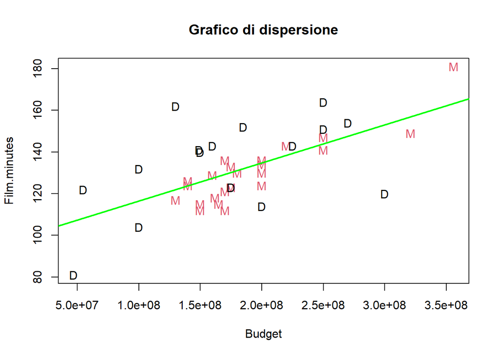

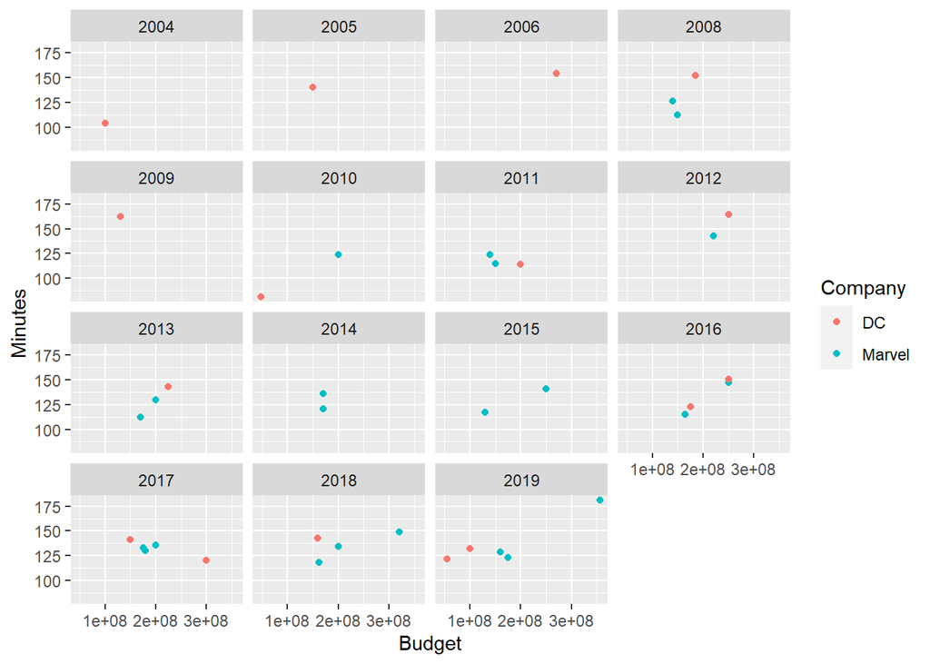

### *Verifico la correlazione tra la variabile Budget e Film.Rate.IMDB, realizzando il grafico di dispersione.*

```
Call:
lm(formula = Film.Rate.IMDB ~ Budget)

Residuals:
    Min      1Q  Median      3Q     Max
-3.5298 -0.2676  0.2378  0.5986  2.0697

Coefficients:
             Estimate Std. Error t value Pr(>|t|)
(Intercept) 6.387e+00  5.151e-01  12.399 9.61e-15 ***
Budget      4.433e-09  2.644e-09   1.676    0.102
---
Signif. codes:  0 '***' 0.001 '**' 0.01 '*' 0.05 '.' 0.1 ' ' 1

Residual standard error: 1.05 on 37 degrees of freedom
Multiple R-squared:  0.07057,   Adjusted R-squared:  0.04545
F-statistic: 2.809 on 1 and 37 DF,  p-value: 0.1021
```

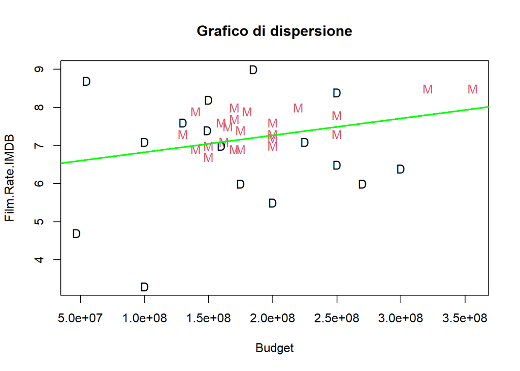

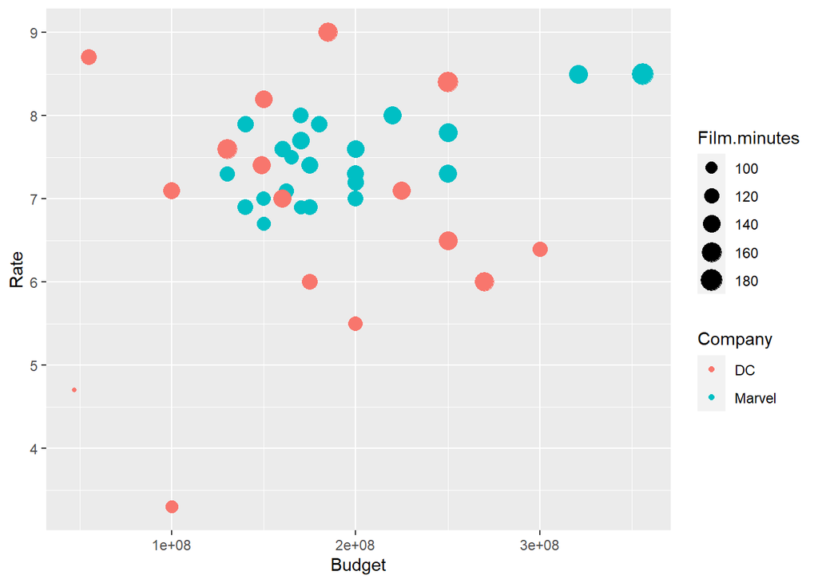

## **VARIABILE OPENING.WEEKEND.USA**

### *Analizzo il summary della variabile Opening.weekend.USA per dedurre il range di valori che assume*

```r
MCU_vs_DCU.df[,9]
```

```
 [1]  98618668  55414050 128122480  65723338  65058524 207438708 174144585
 [8]  85737841  95023721  94320883 191271109  57225526 179139142  85058311
[15] 146510104 117027503 122744989 202003951 257698183  75812205 153433423
[22] 357115007  92579212  16728411  48745440  52535096 158411483  55214334
[29]   5379365  53174303 160887295 116619362 166007347 133682248 103251471
[36]  93842239  67873522  53505326  96202337
```

```r
Opening.weekend.USA=MCU_vs_DCU.df[,9]
summary(Opening.weekend.USA)
```

```
     Min.   1st Qu.    Median      Mean   3rd Qu.      Max.
  5379365  65390931  96202337 115109770 155922453 357115007
```

```r
sum(Opening.weekend.USA)
```

```
[1] 4489281042
```

### *Analizzo il summary della variabile Opening.weekend.USA categorizzata in base alla variabile Company per dedurre il range di valori che assume.*

#### Marvel

```
     Min.   1st Qu.    Median      Mean   3rd Qu.      Max.
 55414050  85398076 117027503 135096585 176641864 357115007
```

#### DC

```
     Min.   1st Qu.    Median      Mean   3rd Qu.      Max.
  5379365  53014501  80857880  86378724 120885084 166007347
```

### *Creiamo ,quindi, boxplot e istogrammi che ci facciano intuire in maniera piu chiara la distribuzione della variabile Opening.weekend.USA generica e relativamente ai film Marvel DC.*

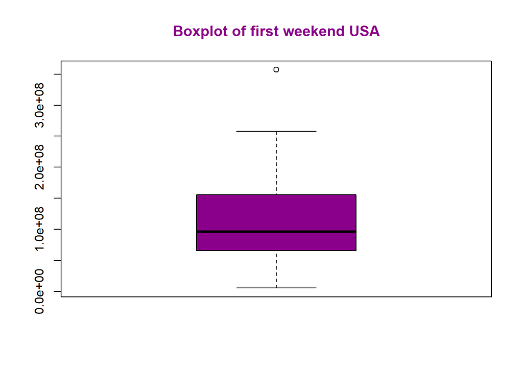

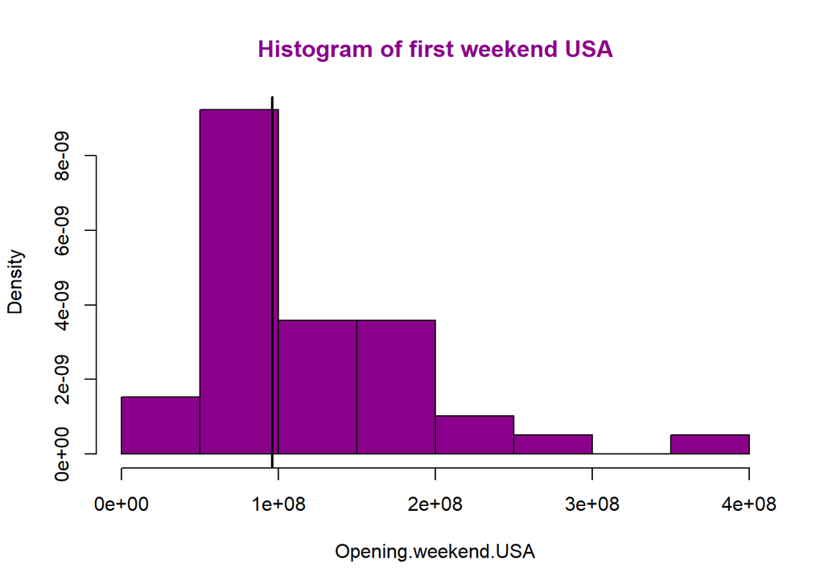

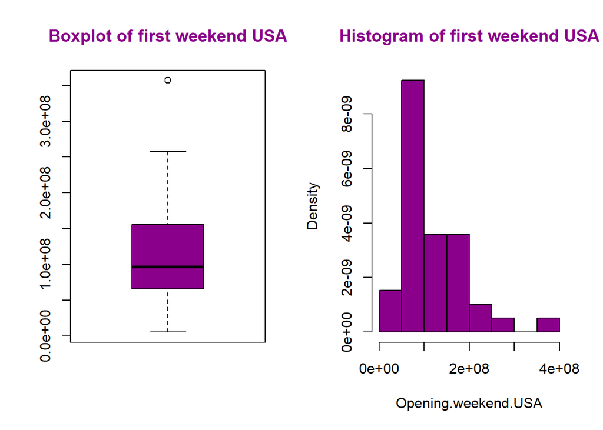

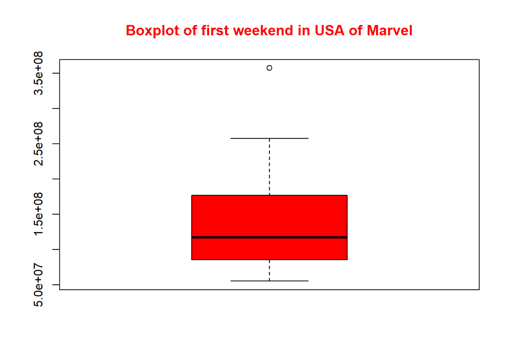

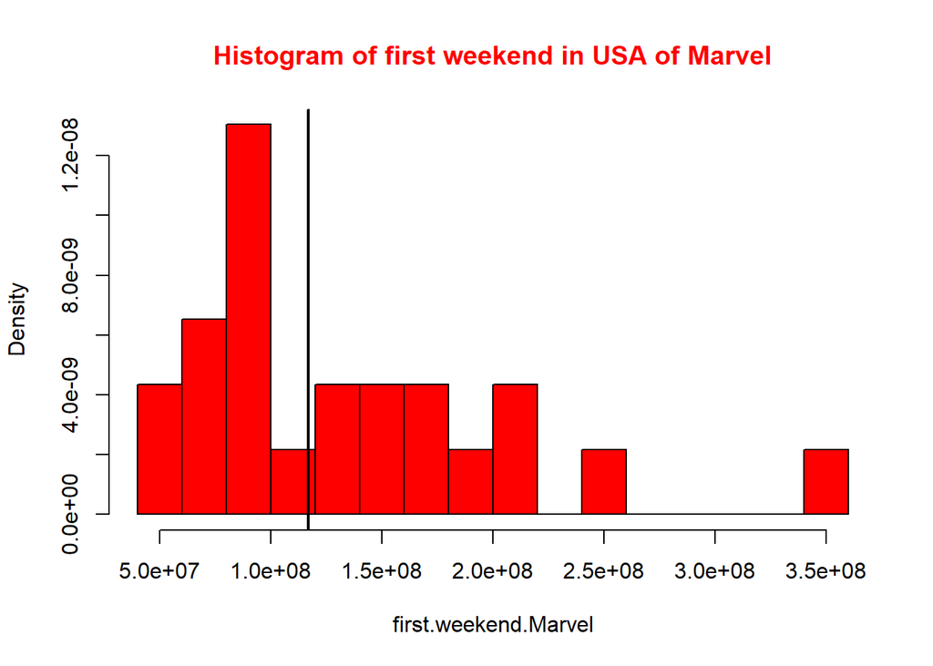

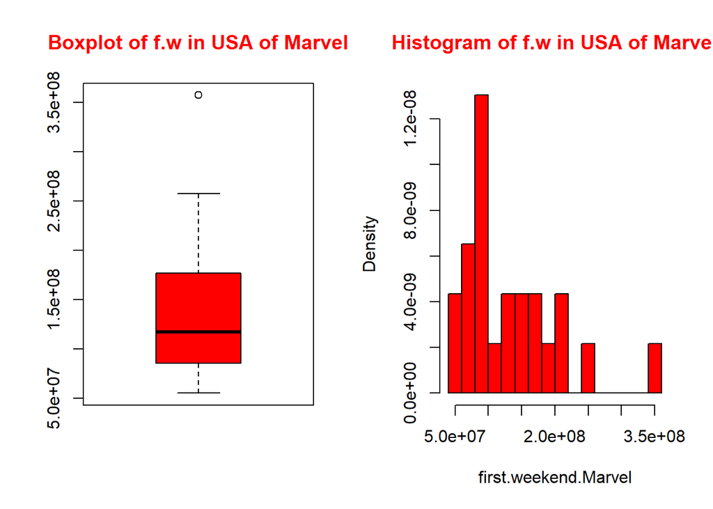

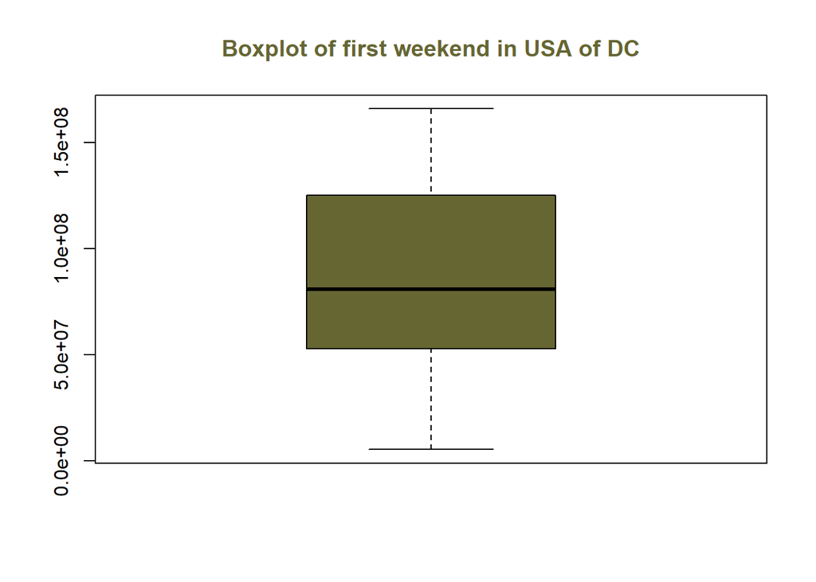

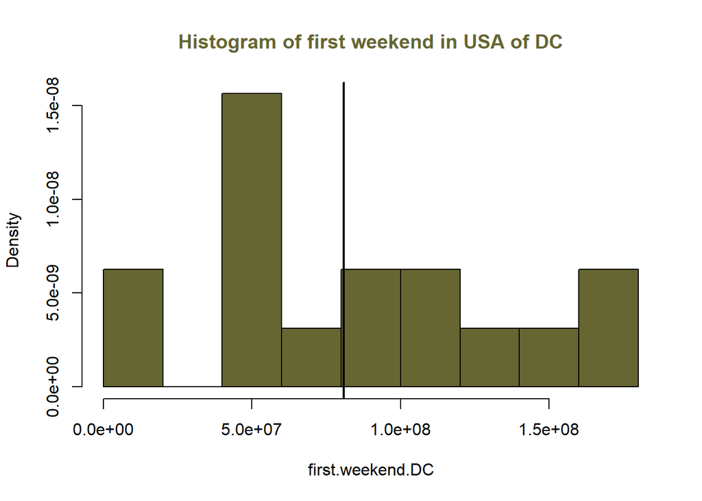

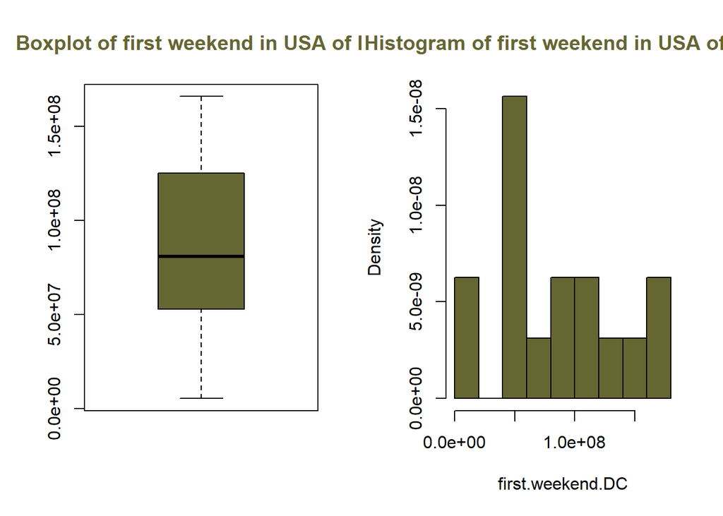

#### *E’ difficile confrontare boxplot e istogrammi che si distribuiscono su scale differenti.*

### *E’ necessario affiancare i boxplot della variabile Opening.weekend.USA di Marvel e DC, in modo da valutare la distribuzione avendo come riferimento la stessa scala*

```
$DC
     Min.   1st Qu.    Median      Mean   3rd Qu.      Max.
  5379365  53014501  80857880  86378724 120885084 166007347

$Marvel
     Min.   1st Qu.    Median      Mean   3rd Qu.      Max.
 55414050  85398076 117027503 135096585 176641864 357115007
```

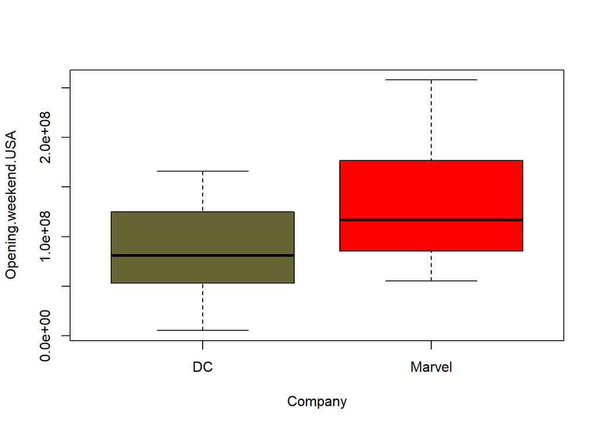

#### -Il primo quartile ed il terzo presentano una netta disparità:

> Per la prima volta la variabilità per una variabile Marvel è più accentuata rispetto a quella DC

### *Creo un istorgamma che metta in relazione la variabile Opening.weekend.USA e la variabile Company*

[figure not shown]

### *Misuro quindi la connessione che c’è tra l’appartenenza ad una determinata casa cinematografica ed il profitto realizzato nel primo weekend di uscita nelle sale USA di un determinato film*

```r
aov.Opening.Weekend.USA=summary(aov(Opening.weekend.USA~Company))

dev.Opening.Weekend.USA=aov.Opening.Weekend.USA[[1]]$`Sum Sq`

eta.quadro.Opening.Weekend.USA=dev.Opening.Weekend.USA[1]/sum(dev.Opening.Weekend.USA)
eta.quadro.Opening.Weekend.USA
```

```
[1] 0.124991
```

#### *Si deduce che la dipendenza in media dalla variabile Company spiega solo il 12.5% della variabilità totale della variabile Opening.weekend.USA*

### *Quale film ha avuto incasso più basso? Quale il più alto?*

```
     Min.   1st Qu.    Median      Mean   3rd Qu.      Max.
  5379365  65390931  96202337 115109770 155922453 357115007
```

```
[1] "Jonah Hex"
```

```
[1] "DC"
```

```
[1] "Avengers: Endgame"
```

```
[1] "Marvel"
```

### *Quanto ha incassato Marvel dalle uscite di tutti i suoi film nel primo weekend di uscita negli USA?*

```
[1] 3107221463
```

### *Quanto ha incassato DC dalle uscite di tutti i suoi film nel primo weekend di uscita negli USA?*

```
[1] 1382059579
```

### *Quanto ha incassato il primo film Marvel ed il primo film DC?*

```
[1] 98618668 55414050
```

```
[1] 16728411
```

### *Verifico la correlazione tra la variabile Opening.weekend.USA e Film.Rate.IMDB, realizzando il grafico di dispersione.*

```
                         Rate Opening.Weekend.USA
Rate                1.0000000           0.5216891
Opening.Weekend.USA 0.5216891           1.0000000
```

```
Call:
lm(formula = Film.Rate.IMDB ~ Opening.weekend.USA)

Residuals:
    Min      1Q  Median      3Q     Max
-3.0993 -0.5682  0.1332  0.5757  1.6518

Coefficients:
                     Estimate Std. Error t value Pr(>|t|)
(Intercept)         6.263e+00  2.932e-01   21.36  < 2e-16 ***
Opening.weekend.USA 8.165e-09  2.195e-09    3.72 0.000659 ***
---
Signif. codes:  0 '***' 0.001 '**' 0.01 '*' 0.05 '.' 0.1 ' ' 1

Residual standard error: 0.9292 on 37 degrees of freedom
Multiple R-squared:  0.2722,    Adjusted R-squared:  0.2525
F-statistic: 13.84 on 1 and 37 DF,  p-value: 0.0006594
```

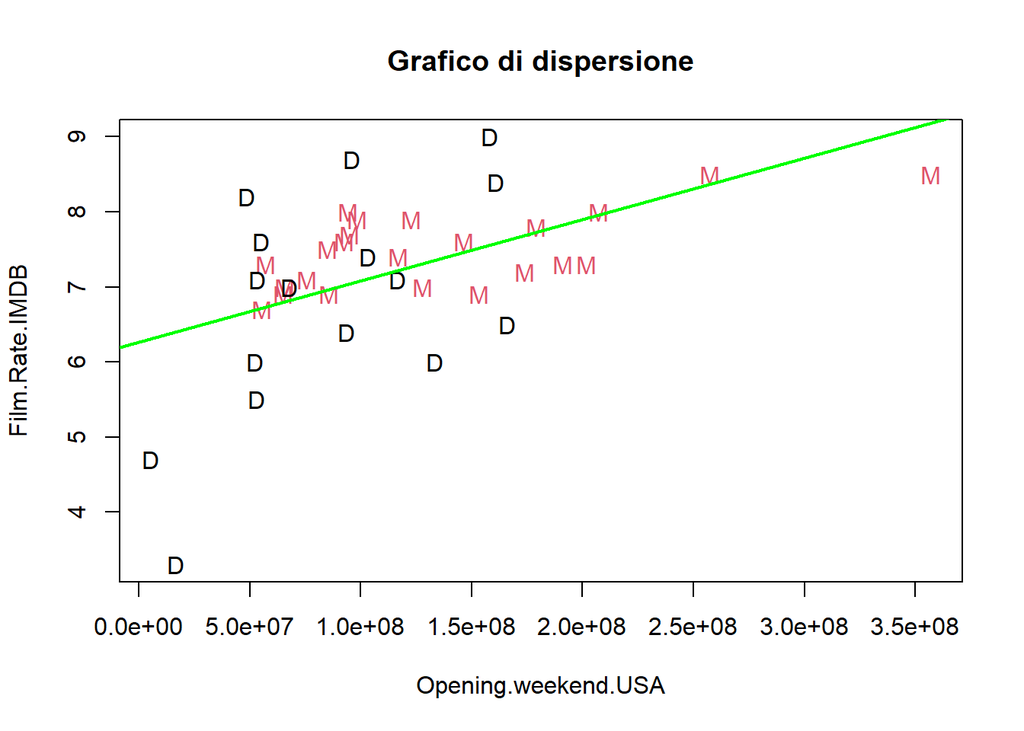

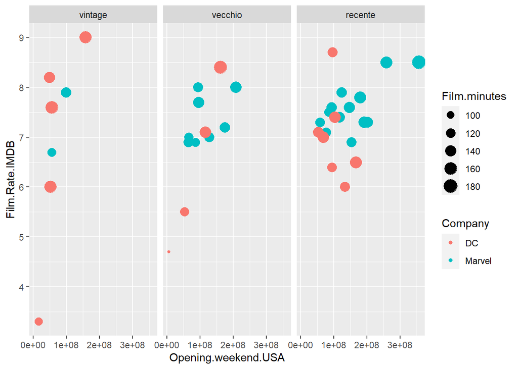

#### *Si nota,quindi, che la correlazione tra Film.Rate.IMDB E Opening.weekend.USA è abbastanza alta, pertanto mi vuol dire quanto è forte il legame simmetrico tra Film.Rate.IMDB e Opening.weekend.USA quando sono paritarie.*

## **VARIABILE GROSS.USA**

### *Analizzo il summary della variabile Gross.USA per dedurre il range di valori che assume*

```r
MCU_vs_DCU.df[,10]
```

```
 [1] 318604126 134806913 312433331 181030624 176654505 623357910 409013994
 [8] 206362140 259766572 333176600 459005868 180202163 408084349 232641920
[15] 389813101 334201140 315058289 700059566 678815482 216648740 426829839
[22] 858373000 390532085  40202379 206852432 200081192 535234033 107509799
[29]  10547117 116601172 448139099 291045518 330360194 325100054 412563408
[36] 229024295 335061807 140371656 333204580
```

```r
Gross.USA=MCU_vs_DCU.df[,10]
summary(Gross.USA)
```

```
     Min.   1st Qu.    Median      Mean   3rd Qu.      Max.
 10547117 203221666 318604126 323265923 408549172 858373000
```

### *Analizzo il summary della variabile Gross.USA categorizzata in base alla variabile Company per dedurre il range di valori che assume.*

#### Marvel

```
     Min.   1st Qu.    Median      Mean   3rd Qu.      Max.
134806913 224645330 333176600 371542272 417921916 858373000
```

#### DC

```
     Min.   1st Qu.    Median      Mean   3rd Qu.      Max.
 10547117 134429035 260034906 253868671 333668887 535234033
```

### *Creiamo ,quindi, boxplot e istogrammi che ci facciano intuire in maniera piu chiara la distribuzione della variabile Gross.USA generica e relativamente ai film Marvel DC.*

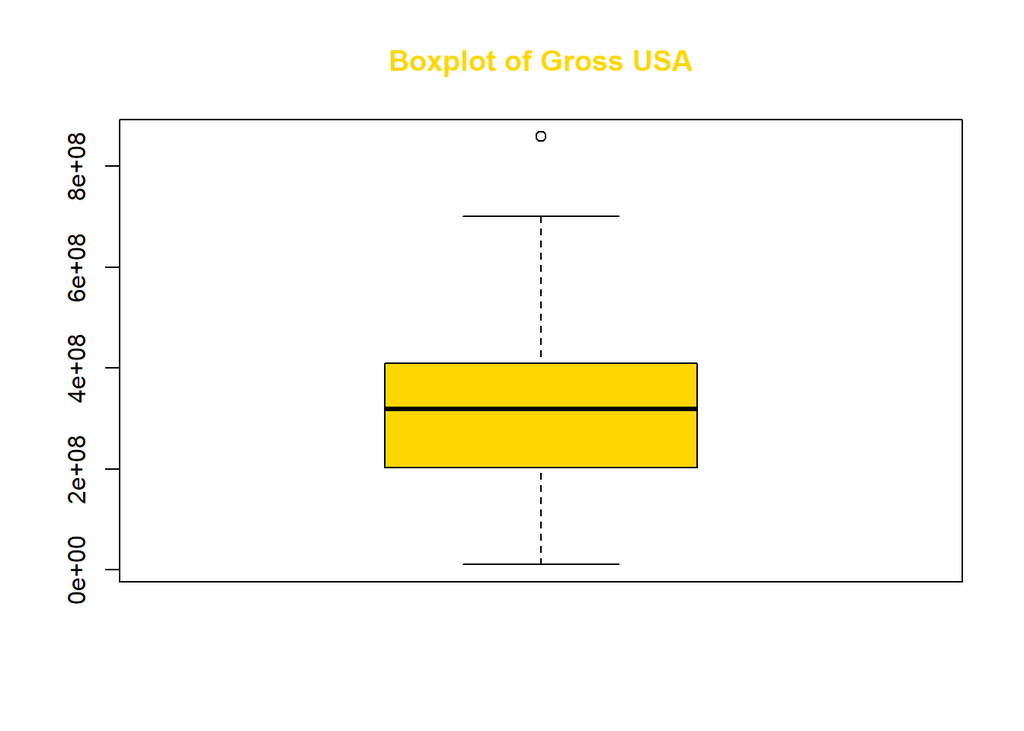

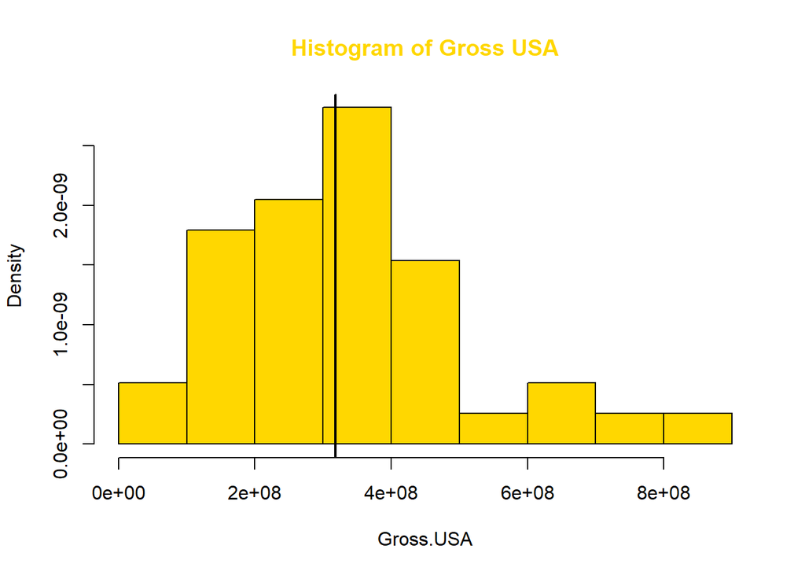

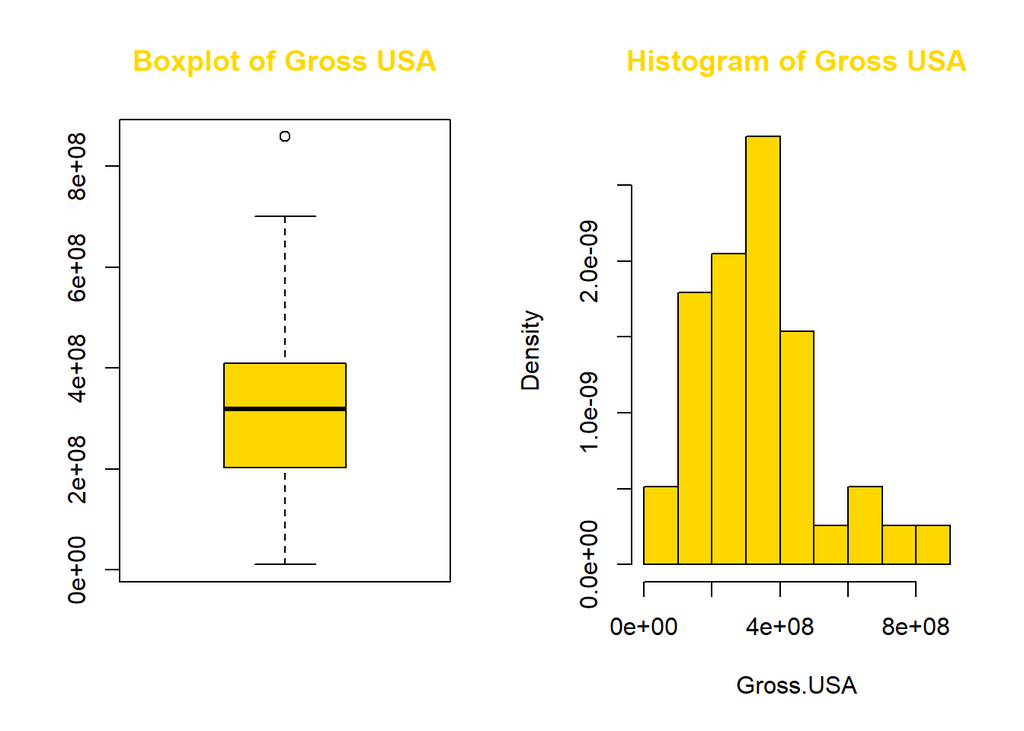

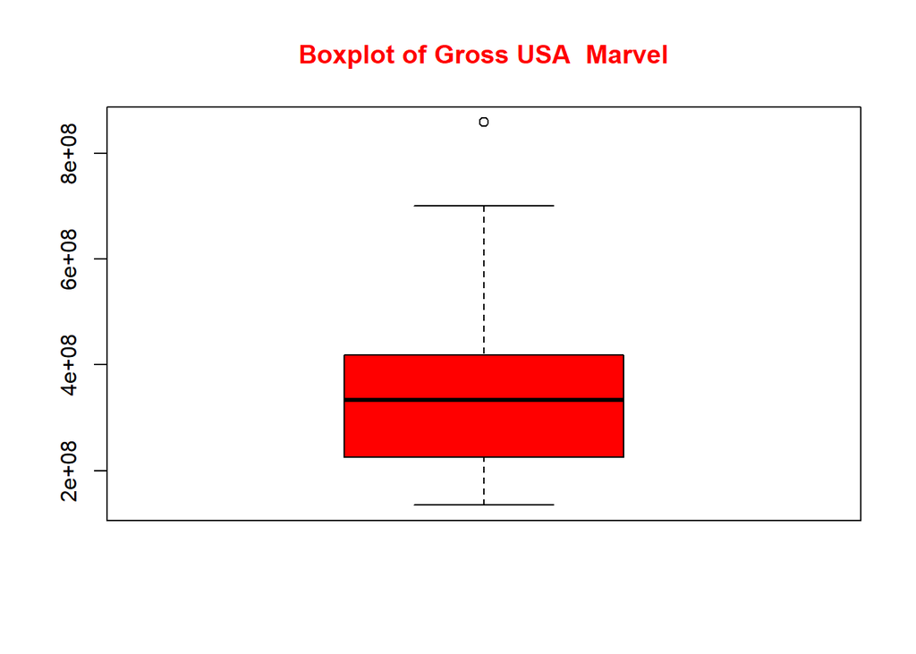